# Review :1- Cricket Performance Analytics

Surya Prasad S

17/03/2021

## Setup

```r
rm(list=ls())
library(dplyr)
```

```r
library(tidyr)
library(ggplot2)
library(ggpubr)
setwd("G:/VIT/Winter Semester 2020-21/Essentials Of Data Analytics/Project")
getwd()
```

```
## [1] "G:/VIT/Winter Semester 2020-21/Essentials Of Data Analytics/Project"
```

## What problem are you trying to solve?

### 1. Evaluating the impact of players in different phases of the game through a performance index considering the match situation and ground conditions. This would help in teams picking the right players for the right roles in their teams. (Player Selection and Team Recommendation)

### 2. Score Predictor and Win Predictor for the given match. The predictor takes into account the Match situation and Ground Conditions (Score, Overs, Number of Wickets Left, Opposition, Ground). This would help the viewers know who is ahead in terms of winning the match. It would also help teams in identifying a winning target to set to win the match.(Target Prediction and Winning Probability)

## What data have you chosen?(Chosen Dataset, Source of dataset, Description of dataset, basic commands to describe dataset)

### Chosen Dataset: Indian Premier League (Cricket) : Ball-By-Ball Cricket Data

### Source of Dataset: Kaggle (https://www.kaggle.com/nowke9/ipldata)

### Description of Dataset:

### All Indian Premier League Cricket matches between 2008 and 2019.

### This is the ball by ball data of all the IPL cricket matches till season 12.

### The dataset contains 2 files: deliveries.csv and matches.csv.

### matches.csv contains details related to the match such as location, contesting teams, umpires, results, etc.

### deliveries.csv is the ball-by-ball data of all the IPL matches including data of the batting team, batsman, bowler, non-striker, runs scored, etc.

```r
deliveries = read.csv("deliveries.csv")
matches = read.csv("matches.csv")
str(deliveries)
```

```
## 'data.frame':    179078 obs. of  21 variables:
##  $ match_id        : int  1 1 1 1 1 1 1 1 1 1 ...
##  $ inning          : int  1 1 1 1 1 1 1 1 1 1 ...
##  $ batting_team    : chr  "Sunrisers Hyderabad" "Sunrisers Hyderabad" "Sunrisers Hyderabad" "Sunrisers Hyderabad" ...
##  $ bowling_team    : chr  "Royal Challengers Bangalore" "Royal Challengers Bangalore" "Royal Challengers Bangalore" "Royal Challengers Bangalore" ...
##  $ over            : int  1 1 1 1 1 1 1 2 2 2 ...
##  $ ball            : int  1 2 3 4 5 6 7 1 2 3 ...
##  $ batsman         : chr  "DA Warner" "DA Warner" "DA Warner" "DA Warner" ...
##  $ non_striker     : chr  "S Dhawan" "S Dhawan" "S Dhawan" "S Dhawan" ...
##  $ bowler          : chr  "TS Mills" "TS Mills" "TS Mills" "TS Mills" ...
##  $ is_super_over   : int  0 0 0 0 0 0 0 0 0 0 ...
##  $ wide_runs       : int  0 0 0 0 2 0 0 0 0 0 ...
##  $ bye_runs        : int  0 0 0 0 0 0 0 0 0 0 ...
##  $ legbye_runs     : int  0 0 0 0 0 0 1 0 0 0 ...
##  $ noball_runs     : int  0 0 0 0 0 0 0 0 0 1 ...
##  $ penalty_runs    : int  0 0 0 0 0 0 0 0 0 0 ...
##  $ batsman_runs    : int  0 0 4 0 0 0 0 1 4 0 ...
##  $ extra_runs      : int  0 0 0 0 2 0 1 0 0 1 ...
##  $ total_runs      : int  0 0 4 0 2 0 1 1 4 1 ...
##  $ player_dismissed: chr  "" "" "" "" ...
##  $ dismissal_kind  : chr  "" "" "" "" ...
##  $ fielder         : chr  "" "" "" "" ...
```

```r
str(matches)
```

```
## 'data.frame':    756 obs. of  18 variables:
##  $ id             : int  1 2 3 4 5 6 7 8 9 10 ...
##  $ season         : int  2017 2017 2017 2017 2017 2017 2017 2017 2017 2017 ...
##  $ city           : chr  "Hyderabad" "Pune" "Rajkot" "Indore" ...
##  $ date           : chr  "2017-04-05" "2017-04-06" "2017-04-07" "2017-04-08" ...
##  $ team1          : chr  "Sunrisers Hyderabad" "Mumbai Indians" "Gujarat Lions" "Rising Pune Supergiant" ...
##  $ team2          : chr  "Royal Challengers Bangalore" "Rising Pune Supergiant" "Kolkata Knight Riders" "Kings XI Punjab" ...
##  $ toss_winner    : chr  "Royal Challengers Bangalore" "Rising Pune Supergiant" "Kolkata Knight Riders" "Kings XI Punjab" ...
##  $ toss_decision  : chr  "field" "field" "field" "field" ...
##  $ result         : chr  "normal" "normal" "normal" "normal" ...
##  $ dl_applied     : int  0 0 0 0 0 0 0 0 0 0 ...
##  $ winner         : chr  "Sunrisers Hyderabad" "Rising Pune Supergiant" "Kolkata Knight Riders" "Kings XI Punjab" ...
##  $ win_by_runs    : int  35 0 0 0 15 0 0 0 97 0 ...
##  $ win_by_wickets : int  0 7 10 6 0 9 4 8 0 4 ...
##  $ player_of_match: chr  "Yuvraj Singh" "SPD Smith" "CA Lynn" "GJ Maxwell" ...
##  $ venue          : chr  "Rajiv Gandhi International Stadium, Uppal" "Maharashtra Cricket Association Stadium" "Saurashtra Cricket Association Stadium" "Holkar Cricket Stadium" ...
##  $ umpire1        : chr  "AY Dandekar" "A Nand Kishore" "Nitin Menon" "AK Chaudhary" ...
##  $ umpire2        : chr  "NJ Llong" "S Ravi" "CK Nandan" "C Shamshuddin" ...
##  $ umpire3        : chr  "" "" "" "" ...
```

```r
head(deliveries,5)
```

```
##   match_id inning        batting_team                bowling_team over ball
## 1        1      1 Sunrisers Hyderabad Royal Challengers Bangalore    1    1
## 2        1      1 Sunrisers Hyderabad Royal Challengers Bangalore    1    2
## 3        1      1 Sunrisers Hyderabad Royal Challengers Bangalore    1    3
## 4        1      1 Sunrisers Hyderabad Royal Challengers Bangalore    1    4
## 5        1      1 Sunrisers Hyderabad Royal Challengers Bangalore    1    5
##     batsman non_striker   bowler is_super_over wide_runs bye_runs legbye_runs
## 1 DA Warner    S Dhawan TS Mills             0         0        0           0
## 2 DA Warner    S Dhawan TS Mills             0         0        0           0
## 3 DA Warner    S Dhawan TS Mills             0         0        0           0
## 4 DA Warner    S Dhawan TS Mills             0         0        0           0
## 5 DA Warner    S Dhawan TS Mills             0         2        0           0
##   noball_runs penalty_runs batsman_runs extra_runs total_runs player_dismissed
## 1           0            0            0          0          0
## 2           0            0            0          0          0
## 3           0            0            4          0          4
## 4           0            0            0          0          0
## 5           0            0            0          2          2
##   dismissal_kind fielder
## 1
## 2
## 3
## 4
## 5
```

```r
head(matches,5)
```

```
##   id season      city       date                       team1
## 1  1   2017 Hyderabad 2017-04-05         Sunrisers Hyderabad
## 2  2   2017      Pune 2017-04-06              Mumbai Indians
## 3  3   2017    Rajkot 2017-04-07               Gujarat Lions
## 4  4   2017    Indore 2017-04-08      Rising Pune Supergiant
## 5  5   2017 Bangalore 2017-04-08 Royal Challengers Bangalore
##                         team2                 toss_winner toss_decision result
## 1 Royal Challengers Bangalore Royal Challengers Bangalore         field normal
## 2      Rising Pune Supergiant      Rising Pune Supergiant         field normal
## 3       Kolkata Knight Riders       Kolkata Knight Riders         field normal
## 4             Kings XI Punjab             Kings XI Punjab         field normal
## 5            Delhi Daredevils Royal Challengers Bangalore           bat normal
##   dl_applied                      winner win_by_runs win_by_wickets
## 1          0         Sunrisers Hyderabad          35              0
## 2          0      Rising Pune Supergiant           0              7
## 3          0       Kolkata Knight Riders           0             10
## 4          0             Kings XI Punjab           0              6
## 5          0 Royal Challengers Bangalore          15              0
##   player_of_match                                     venue        umpire1
## 1    Yuvraj Singh Rajiv Gandhi International Stadium, Uppal    AY Dandekar
## 2       SPD Smith   Maharashtra Cricket Association Stadium A Nand Kishore
## 3         CA Lynn    Saurashtra Cricket Association Stadium    Nitin Menon
## 4      GJ Maxwell                    Holkar Cricket Stadium   AK Chaudhary
## 5       KM Jadhav                     M Chinnaswamy Stadium
##         umpire2 umpire3
## 1      NJ Llong
## 2        S Ravi
## 3     CK Nandan
## 4 C Shamshuddin
## 5
```

```r
View(deliveries)
View(matches)
```

## Frame your objectives

### 1. Auction Model for Player Selection and Team Recommendation using Player Performance Index

### 2. Score Predictor for knowing the batting pattern of teams

### 3. Win Predictor for knowing who is winning the match

## Data Cleaning

### Cleaning deliveries.csv

```r
sum(is.na(deliveries))
```

```
## [1] 0
```

#### Replacing the names of the teams with their respective abbreviations

```r
deliveries = deliveries %>%
  mutate(batting_team = replace(batting_team,batting_team == "Royal Challengers Bangalore", "RCB"))

deliveries = deliveries %>%
  mutate(batting_team = replace(batting_team,batting_team == "Sunrisers Hyderabad", "SRH"))

deliveries = deliveries %>%
  mutate(batting_team = replace(batting_team,batting_team == "Chennai Super Kings", "CSK"))

deliveries = deliveries %>%
  mutate(batting_team = replace(batting_team,batting_team == "Mumbai Indians", "MI"))

deliveries = deliveries %>%
  mutate(batting_team = replace(batting_team,batting_team == "Kolkata Knight Riders", "KKR"))

deliveries = deliveries %>%
  mutate(batting_team = replace(batting_team,batting_team == "Delhi Daredevils", "DC"))

deliveries = deliveries %>%
  mutate(batting_team = replace(batting_team,batting_team == "Delhi Capitals", "DC"))

deliveries = deliveries %>%
  mutate(batting_team = replace(batting_team,batting_team == "Rajasthan Royals", "RR"))

deliveries = deliveries %>%
  mutate(batting_team = replace(batting_team,batting_team == "Deccan Chargers", "SRH"))

deliveries = deliveries %>%
  mutate(batting_team = replace(batting_team,batting_team == "Rising Pune Supergiant", "RPS"))

deliveries = deliveries %>%
  mutate(batting_team = replace(batting_team,batting_team == "Rising Pune Supergiants", "RPS"))

deliveries = deliveries%>%
  mutate(batting_team = replace(batting_team,batting_team == "Pune Warriors", "RPS"))

deliveries= deliveries %>%
  mutate(batting_team = replace(batting_team,batting_team == "Kings XI Punjab", "KXIP"))

deliveries = deliveries %>%
  mutate(batting_team = replace(batting_team,batting_team == "Gujarat Lions", "GL"))

deliveries = deliveries %>%
  mutate(batting_team = replace(batting_team,batting_team == "Kochi Tuskers Kerala", "KTK"))

unique(deliveries$batting_team)
```

```
##  [1] "SRH"  "RCB"  "MI"   "RPS"  "GL"   "KKR"  "KXIP" "DC"   "CSK"  "RR"
## [11] "KTK"
```

```r
deliveries = deliveries %>%
  mutate(bowling_team = replace(bowling_team,bowling_team == "Royal Challengers Bangalore", "RCB"))

deliveries = deliveries %>%
  mutate(bowling_team = replace(bowling_team,bowling_team == "Sunrisers Hyderabad", "SRH"))

deliveries = deliveries %>%
  mutate(bowling_team = replace(bowling_team,bowling_team == "Chennai Super Kings", "CSK"))

deliveries = deliveries %>%
  mutate(bowling_team = replace(bowling_team,bowling_team == "Mumbai Indians", "MI"))

deliveries = deliveries %>%
  mutate(bowling_team = replace(bowling_team,bowling_team == "Kolkata Knight Riders", "KKR"))

deliveries = deliveries %>%
  mutate(bowling_team = replace(bowling_team,bowling_team == "Delhi Daredevils", "DC"))

deliveries = deliveries %>%
  mutate(bowling_team = replace(bowling_team,bowling_team == "Delhi Capitals", "DC"))

deliveries = deliveries %>%
  mutate(bowling_team = replace(bowling_team,bowling_team == "Rajasthan Royals", "RR"))

deliveries = deliveries %>%
  mutate(bowling_team = replace(bowling_team,bowling_team == "Deccan Chargers", "SRH"))

deliveries = deliveries %>%
  mutate(bowling_team = replace(bowling_team,bowling_team == "Rising Pune Supergiant", "RPS"))

deliveries = deliveries %>%
  mutate(bowling_team = replace(bowling_team,bowling_team == "Rising Pune Supergiants", "RPS"))

deliveries = deliveries %>%
  mutate(bowling_team = replace(bowling_team,bowling_team == "Pune Warriors", "RPS"))

deliveries = deliveries %>%
  mutate(bowling_team = replace(bowling_team,bowling_team == "Kings XI Punjab", "KXIP"))

deliveries = deliveries %>%
  mutate(bowling_team = replace(bowling_team,bowling_team == "Gujarat Lions", "GL"))

deliveries = deliveries %>%
  mutate(bowling_team = replace(bowling_team,bowling_team == "Kochi Tuskers Kerala", "KTK"))

unique(deliveries$bowling_team)
```

```
##  [1] "RCB"  "SRH"  "RPS"  "MI"   "KKR"  "GL"   "KXIP" "DC"   "CSK"  "RR"
## [11] "KTK"
```

#### Adding some more columns to the dataset for clarity of mode of dismissal and runs scored

```r
deliveries$dismissal_kind = deliveries$dismissal_kind %>% as.character()
deliveries$wicket = ifelse((deliveries$dismissal_kind=="" | deliveries$dismissal_kind=="run out"), 0, 1)
deliveries$dismissal = ifelse((deliveries$dismissal_kind==""), 0, 1)
deliveries$dot = ifelse((deliveries$total_runs==0), 1, 0)
deliveries$boundary = ifelse((deliveries$total_runs==4 | deliveries$total_runs==6), 1, 0)
deliveries$singles = if_else((deliveries$total_runs==1 | deliveries$total_runs==2 | deliveries$total_runs==3),1,0)
```

### Cleaning matches.csv

#### Dropping the Umpire 1 ,2, 3 Column from the dataset since it is not required for analysis

```r
sum(is.na(matches))
```

```
## [1] 0
```

```r
sum(is.na(matches$umpire3))
```

```
## [1] 0
```

```r
matches$umpire3 = NULL
matches$umpire1 = NULL
matches$umpire2 = NULL
```

#### Renaming names of teams with their abbreviations

```r
matches = matches %>%
  mutate(team1 = replace(team1,team1 == "Royal Challengers Bangalore", "RCB"))

matches = matches %>%
  mutate(team1 = replace(team1,team1 == "Sunrisers Hyderabad", "SRH"))

matches = matches %>%
  mutate(team1 = replace(team1,team1 == "Chennai Super Kings", "CSK"))

matches = matches %>%
  mutate(team1 = replace(team1,team1 == "Mumbai Indians", "MI"))

matches = matches %>%
  mutate(team1 = replace(team1,team1 == "Kolkata Knight Riders", "KKR"))

matches = matches %>%
  mutate(team1 = replace(team1,team1 == "Delhi Daredevils", "DC"))

matches = matches %>%
  mutate(team1 = replace(team1,team1 == "Delhi Capitals", "DC"))

matches = matches %>%
  mutate(team1 = replace(team1,team1 == "Rajasthan Royals", "RR"))

matches = matches %>%
  mutate(team1 = replace(team1,team1 == "Deccan Chargers", "SRH"))

matches = matches %>%
  mutate(team1 = replace(team1,team1 == "Rising Pune Supergiant", "RPS"))

matches = matches %>%
  mutate(team1 = replace(team1,team1 == "Rising Pune Supergiants", "RPS"))

matches = matches %>%
  mutate(team1 = replace(team1,team1 == "Pune Warriors", "RPS"))

matches = matches %>%
  mutate(team1 = replace(team1,team1 == "Kings XI Punjab", "KXIP"))

matches = matches %>%
  mutate(team1 = replace(team1,team1 == "Gujarat Lions", "GL"))

matches = matches %>%
  mutate(team1 = replace(team1,team1 == "Kochi Tuskers Kerala", "KTK"))

unique(matches$team1)
```

```
##  [1] "SRH"  "MI"   "GL"   "RPS"  "RCB"  "KKR"  "DC"   "KXIP" "CSK"  "RR"
## [11] "KTK"
```

```r
matches = matches %>%
  mutate(team2 = replace(team2,team2 == "Royal Challengers Bangalore", "RCB"))

matches = matches %>%
  mutate(team2 = replace(team2,team2 == "Sunrisers Hyderabad", "SRH"))

matches = matches %>%
  mutate(team2 = replace(team2,team2 == "Chennai Super Kings", "CSK"))

matches = matches %>%
  mutate(team2 = replace(team2,team2 == "Mumbai Indians", "MI"))

matches = matches %>%
  mutate(team2 = replace(team2,team2 == "Kolkata Knight Riders", "KKR"))

matches = matches %>%
  mutate(team2 = replace(team2,team2 == "Delhi Daredevils", "DC"))

matches = matches %>%
  mutate(team2 = replace(team2,team2 == "Delhi Capitals", "DC"))

matches = matches %>%
  mutate(team2 = replace(team2,team2 == "Rajasthan Royals", "RR"))

matches = matches %>%
  mutate(team2 = replace(team2,team2 == "Deccan Chargers", "SRH"))

matches = matches %>%
  mutate(team2 = replace(team2,team2 == "Rising Pune Supergiant", "RPS"))

matches = matches %>%
  mutate(team2 = replace(team2,team2 == "Rising Pune Supergiants", "RPS"))

matches = matches %>%
  mutate(team2 = replace(team2,team2 == "Pune Warriors", "RPS"))

matches = matches %>%
  mutate(team2 = replace(team2,team2 == "Kings XI Punjab", "KXIP"))

matches = matches %>%
  mutate(team2 = replace(team2,team2 == "Gujarat Lions", "GL"))

matches = matches %>%
  mutate(team2 = replace(team2,team2 == "Kochi Tuskers Kerala", "KTK"))

unique(matches$team2)
```

```
##  [1] "RCB"  "RPS"  "KKR"  "KXIP" "DC"   "SRH"  "MI"   "GL"   "RR"   "CSK"
## [11] "KTK"
```

```r
matches = matches %>%
  mutate(toss_winner = replace(toss_winner,toss_winner == "Royal Challengers Bangalore", "RCB"))

matches = matches %>%
  mutate(toss_winner = replace(toss_winner,toss_winner == "Sunrisers Hyderabad", "SRH"))

matches = matches %>%
  mutate(toss_winner = replace(toss_winner,toss_winner == "Chennai Super Kings", "CSK"))

matches = matches %>%
  mutate(toss_winner = replace(toss_winner,toss_winner == "Mumbai Indians", "MI"))

matches = matches %>%
  mutate(toss_winner = replace(toss_winner,toss_winner == "Kolkata Knight Riders", "KKR"))

matches = matches %>%
  mutate(toss_winner = replace(toss_winner,toss_winner == "Delhi Daredevils", "DC"))

matches = matches %>%
  mutate(toss_winner = replace(toss_winner,toss_winner == "Delhi Capitals", "DC"))

matches = matches %>%
  mutate(toss_winner = replace(toss_winner,toss_winner == "Rajasthan Royals", "RR"))

matches = matches %>%
  mutate(toss_winner = replace(toss_winner,toss_winner == "Deccan Chargers", "SRH"))

matches = matches %>%
  mutate(toss_winner = replace(toss_winner,toss_winner == "Rising Pune Supergiant", "RPS"))

matches = matches %>%
  mutate(toss_winner = replace(toss_winner,toss_winner == "Rising Pune Supergiants", "RPS"))

matches = matches %>%
  mutate(toss_winner = replace(toss_winner,toss_winner == "Pune Warriors", "RPS"))

matches = matches %>%
  mutate(toss_winner = replace(toss_winner,toss_winner == "Kings XI Punjab", "KXIP"))

matches = matches %>%
  mutate(toss_winner = replace(toss_winner,toss_winner == "Gujarat Lions", "GL"))

matches = matches %>%
  mutate(toss_winner = replace(toss_winner,toss_winner == "Kochi Tuskers Kerala", "KTK"))

unique(matches$toss_winner)
```

```
##  [1] "RCB"  "RPS"  "KKR"  "KXIP" "SRH"  "MI"   "GL"   "DC"   "CSK"  "RR"
## [11] "KTK"
```

```r
matches = matches %>%
  mutate(winner = replace(winner,winner == "Royal Challengers Bangalore", "RCB"))

matches = matches %>%
  mutate(winner = replace(winner,winner == "Sunrisers Hyderabad", "SRH"))

matches = matches %>%
  mutate(winner = replace(winner,winner == "Chennai Super Kings", "CSK"))

matches = matches %>%
  mutate(winner = replace(winner,winner == "Mumbai Indians", "MI"))

matches = matches %>%
  mutate(winner = replace(winner,winner == "Kolkata Knight Riders", "KKR"))

matches = matches %>%
  mutate(winner = replace(winner,winner == "Delhi Daredevils", "DC"))

matches = matches %>%
  mutate(winner = replace(winner,winner == "Delhi Capitals", "DC"))

matches = matches %>%
  mutate(winner = replace(winner,winner == "Rajasthan Royals", "RR"))

matches = matches %>%
  mutate(winner = replace(winner,winner == "Deccan Chargers", "SRH"))

matches = matches %>%
  mutate(winner = replace(winner,winner == "Rising Pune Supergiant", "RPS"))

matches = matches %>%
  mutate(winner = replace(winner,winner == "Rising Pune Supergiants", "RPS"))

matches = matches %>%
  mutate(winner = replace(winner,winner == "Pune Warriors", "RPS"))

matches = matches %>%
  mutate(winner = replace(winner,winner == "Kings XI Punjab", "KXIP"))

matches = matches %>%
  mutate(winner = replace(winner,winner == "Gujarat Lions", "GL"))

matches = matches %>%
  mutate(winner = replace(winner,winner == "Kochi Tuskers Kerala", "KTK"))

matches  = matches %>%
   mutate(winner = replace(winner,winner == "", "None"))

unique(matches$winner)
```

```
##  [1] "SRH"  "RPS"  "KKR"  "KXIP" "RCB"  "MI"   "DC"   "GL"   "CSK"  "RR"
## [11] "KTK"  "None"
```

#### Replacing missing value in the City Column

```r
matches = matches %>%
  mutate(city = replace(city,city == "","Dubai"))
unique(matches$city)
```

```
##  [1] "Hyderabad"      "Pune"           "Rajkot"         "Indore"
##  [5] "Bangalore"      "Mumbai"         "Kolkata"        "Delhi"
##  [9] "Chandigarh"     "Kanpur"         "Jaipur"         "Chennai"
## [13] "Cape Town"      "Port Elizabeth" "Durban"         "Centurion"
## [17] "East London"    "Johannesburg"   "Kimberley"      "Bloemfontein"
## [21] "Ahmedabad"      "Cuttack"        "Nagpur"         "Dharamsala"
## [25] "Kochi"          "Visakhapatnam"  "Raipur"         "Ranchi"
## [29] "Abu Dhabi"      "Sharjah"        "Dubai"          "Mohali"
## [33] "Bengaluru"
```

## Merging 2 datasets

```r
dataset = merge(deliveries,matches,by.x = "match_id", by.y = "id")
View(dataset)
summary(dataset)
```

```
##     match_id         inning      batting_team       bowling_team
##  Min.   :    1   Min.   :1.000   Length:179078      Length:179078
##  1st Qu.:  190   1st Qu.:1.000   Class :character   Class :character
##  Median :  379   Median :1.000   Mode  :character   Mode  :character
##  Mean   : 1802   Mean   :1.483
##  3rd Qu.:  567   3rd Qu.:2.000
##  Max.   :11415   Max.   :5.000
##       over            ball         batsman          non_striker
##  Min.   : 1.00   Min.   :1.000   Length:179078      Length:179078
##  1st Qu.: 5.00   1st Qu.:2.000   Class :character   Class :character
##  Median :10.00   Median :4.000   Mode  :character   Mode  :character
##  Mean   :10.16   Mean   :3.616
##  3rd Qu.:15.00   3rd Qu.:5.000
##  Max.   :20.00   Max.   :9.000
##     bowler          is_super_over         wide_runs          bye_runs
##  Length:179078      Min.   :0.0000000   Min.   :0.00000   Min.   :0.000000
##  Class :character   1st Qu.:0.0000000   1st Qu.:0.00000   1st Qu.:0.000000
##  Mode  :character   Median :0.0000000   Median :0.00000   Median :0.000000
##                     Mean   :0.0004523   Mean   :0.03672   Mean   :0.004936
##                     3rd Qu.:0.0000000   3rd Qu.:0.00000   3rd Qu.:0.000000
##                     Max.   :1.0000000   Max.   :5.00000   Max.   :4.000000
##   legbye_runs       noball_runs        penalty_runs      batsman_runs
##  Min.   :0.00000   Min.   :0.000000   Min.   :0.0e+00   Min.   :0.000
##  1st Qu.:0.00000   1st Qu.:0.000000   1st Qu.:0.0e+00   1st Qu.:0.000
##  Median :0.00000   Median :0.000000   Median :0.0e+00   Median :1.000
##  Mean   :0.02114   Mean   :0.004183   Mean   :5.6e-05   Mean   :1.247
##  3rd Qu.:0.00000   3rd Qu.:0.000000   3rd Qu.:0.0e+00   3rd Qu.:1.000
##  Max.   :5.00000   Max.   :5.000000   Max.   :5.0e+00   Max.   :7.000
##    extra_runs        total_runs     player_dismissed   dismissal_kind
##  Min.   :0.00000   Min.   : 0.000   Length:179078      Length:179078
##  1st Qu.:0.00000   1st Qu.: 0.000   Class :character   Class :character
##  Median :0.00000   Median : 1.000   Mode  :character   Mode  :character
##  Mean   :0.06703   Mean   : 1.314
##  3rd Qu.:0.00000   3rd Qu.: 1.000
##  Max.   :7.00000   Max.   :10.000
##    fielder              wicket          dismissal            dot
##  Length:179078      Min.   :0.00000   Min.   :0.00000   Min.   :0.0000
##  Class :character   1st Qu.:0.00000   1st Qu.:0.00000   1st Qu.:0.0000
##  Mode  :character   Median :0.00000   Median :0.00000   Median :0.0000
##                     Mean   :0.04457   Mean   :0.04933   Mean   :0.3518
```

[output cut: 15 more lines]

```
##
##  toss_decision         result            dl_applied         winner
##  Length:179078      Length:179078      Min.   :0.00000   Length:179078
##  Class :character   Class :character   1st Qu.:0.00000   Class :character
##  Mode  :character   Mode  :character   Median :0.00000   Mode  :character
##                                        Mean   :0.01791
##                                        3rd Qu.:0.00000
##                                        Max.   :1.00000
##   win_by_runs    win_by_wickets   player_of_match       venue
##  Min.   :  0.0   Min.   : 0.000   Length:179078      Length:179078
##  1st Qu.:  0.0   1st Qu.: 0.000   Class :character   Class :character
##  Median :  0.0   Median : 3.000   Mode  :character   Mode  :character
##  Mean   : 13.4   Mean   : 3.262
##  3rd Qu.: 19.0   3rd Qu.: 6.000
##  Max.   :146.0   Max.   :10.000
```

## Basic Analysis

### 1. Top 10 Teams with Most Wins

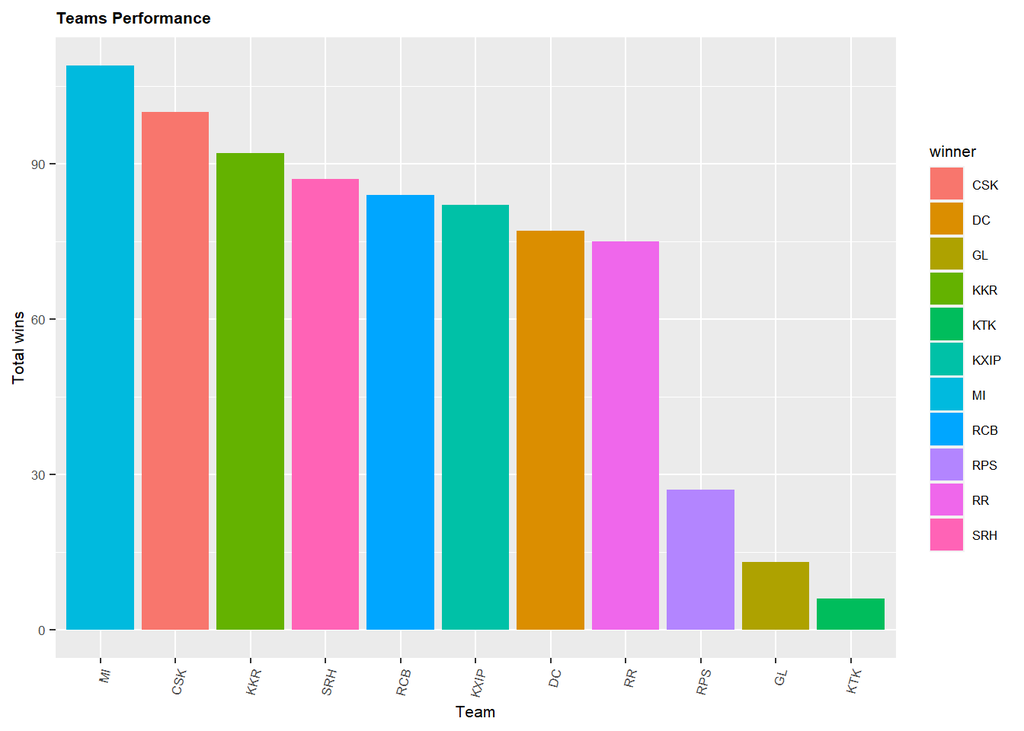

```r
 dataset %>%
  filter(result == "normal" | result == "tie") %>%
  group_by(winner) %>%
  summarise(Wins = n_distinct(match_id)) %>%
  ggplot(aes(x = reorder(winner, -Wins), y = Wins))+geom_bar(aes(fill = winner), stat = "identity")+
  labs(title = "Teams Performance", x = "Team", y = "Total wins")+
  theme(axis.text.x=element_text(angle=75, hjust=1), plot.title = element_text(size = 8, face = "bold"),text = element_text(size=8))
```

#### Inference: MI and CSK are the best teams in the competition with more than 80 wins across the 12 years of the tournament.

### 2. Top 10 Batsman with Most Runs

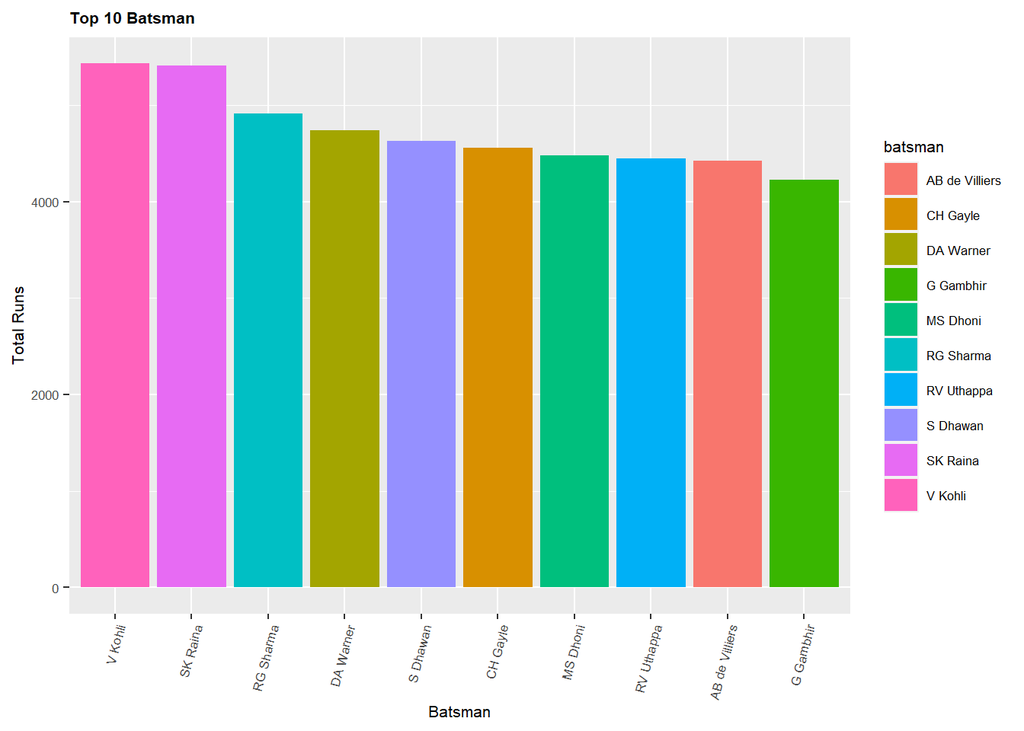

```r
dataset %>%
  group_by(batsman) %>%
  summarise(total_runs = sum(batsman_runs)) %>%
  arrange(desc(total_runs)) %>%
  top_n(n = 10, wt = total_runs) %>%
  ggplot(aes(x = reorder(batsman, -total_runs), y = total_runs))+
  geom_bar(aes(fill = batsman),stat = "identity")+
  labs(title = "Top 10 Batsman", x = "Batsman", y = "Total Runs")+
  theme(axis.text.x=element_text(angle=75, hjust=1), plot.title = element_text(size = 8, face = "bold"),text = element_text(size=8))
```

#### Inference: Virat Kohli and Raina have the best performers with the bat with more than 4000 runs in 12 years of the tournament.

### 3. Top 10 Bowlers with Most Wickets

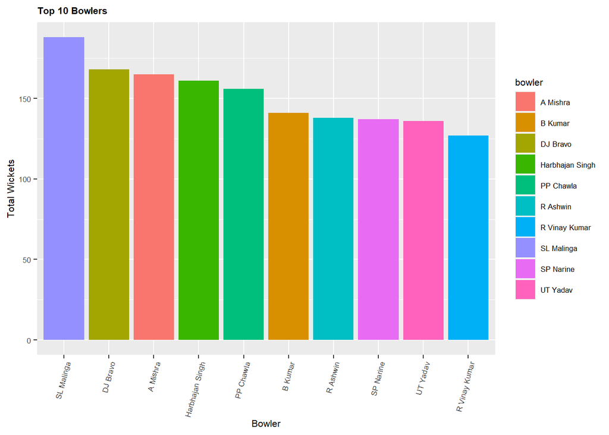

```r
dataset %>%
  group_by(bowler) %>%
  summarise(total_wickets = sum(dismissal)) %>%
  arrange(desc(total_wickets)) %>%
  top_n(n= 10, wt = total_wickets) %>%
  ggplot(aes(x = reorder(bowler,-total_wickets), y= total_wickets))+
  geom_bar(aes(fill= bowler), stat = "identity")+
  labs(title = "Top 10 Bowlers", x = "Bowler", y = "Total Wickets")+
  theme(axis.text.x=element_text(angle=75, hjust=1), plot.title = element_text(size = 8, face = "bold"),text = element_text(size=8))
```

#### Inference: Malinga and Bravo have been the highest wicket takers in the tournament with more than 150 wickets. Amit Mishra is the highest wicket taker among spinners.

### 4. Top 10 Fielders with Most Catches

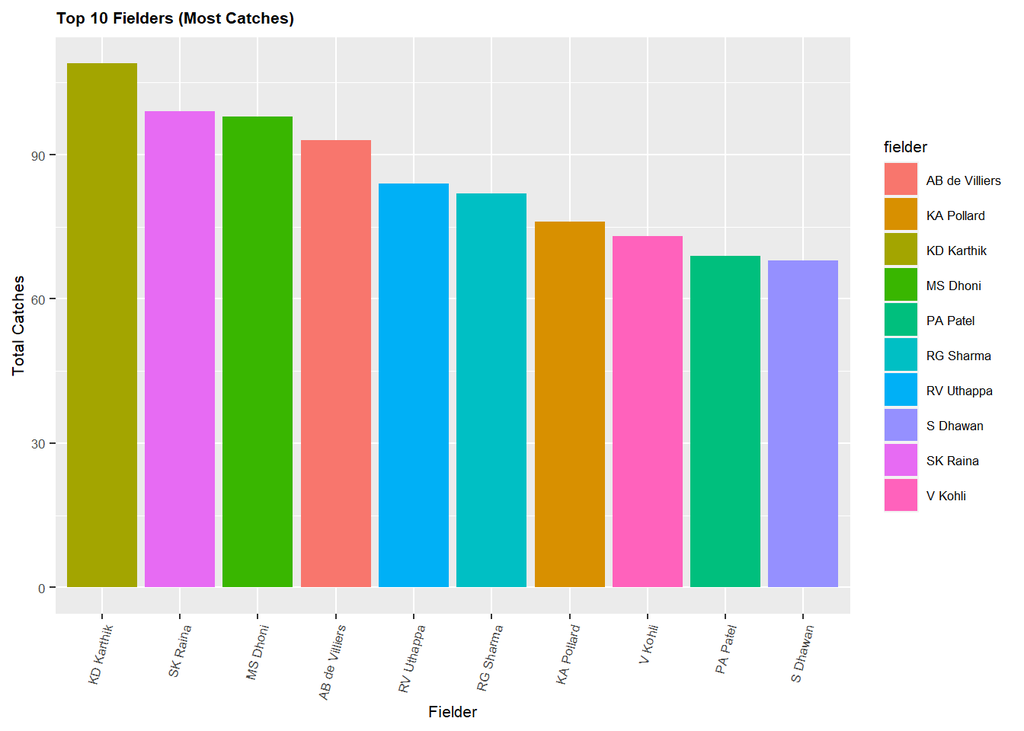

```r
dataset %>%
group_by(fielder) %>%
summarise(total_catches = length(dismissal_kind[dismissal_kind=="caught"])) %>%
arrange(desc(total_catches)) %>%
top_n(n= 10, wt = total_catches) %>%
ggplot(aes(x = reorder(fielder, -total_catches), y= total_catches))+
geom_bar(aes(fill= fielder), stat = "identity")+
labs(title = "Top 10 Fielders (Most Catches)", x = "Fielder", y = "Total Catches")+
theme(axis.text.x=element_text(angle=75, hjust=1), plot.title = element_text(size = 8, face = "bold"),text = element_text(size=8))
```

#### Inference: MS Dhoni and Dinesh Karthik have been the top wicket keepers in the tournament while Raina has been the best fielder in the league with the most catches.

### 5. Team Performance at Home and Away Matches through win percentage

```r
t <- dataset %>%
  filter((result=="normal" | result == "tie") & batting_team %in% c("KKR","CSK","DC","MI","SRH","RCB","RR","KXIP"))

kkr_match_played <- t %>%
  filter(batting_team=="KKR") %>%
  mutate(ground_type = if_else(city == "Kolkata","Home","Away")) %>%
  group_by(ground_type) %>%
  summarise(total_match_played = n_distinct(match_id))
kkr_match_won <- t %>%
  filter(batting_team=="KKR" & winner == "KKR") %>%
  mutate(ground_type = if_else(city == "Kolkata","Home","Away")) %>%
  group_by(ground_type) %>%
  summarise(total_win = n_distinct(match_id))
KKR<-merge(kkr_match_played, kkr_match_won, by ="ground_type")

KKR<-KKR %>%
  mutate(winning_perc = (total_win/total_match_played)*100,
         team = "KKR")

csk_match_played<-t %>%
  filter(batting_team=="CSK") %>%
  mutate(ground_type = if_else(city == "Chennai","Home","Away")) %>%
  group_by(ground_type) %>%
  summarise(total_match_played = n_distinct(match_id))
csk_match_won<-t %>%
  filter(batting_team=="CSK" & winner == "CSK") %>%
  mutate(ground_type = if_else(city == "Chennai","Home","Away")) %>%
  group_by(ground_type) %>%
  summarise(total_win = n_distinct(match_id))
CSK<-merge(csk_match_played, csk_match_won, by ="ground_type")

CSK<-CSK %>%
  mutate(winning_perc = (total_win/total_match_played)*100,
         team ="CSK")

mi_match_played<-t %>%
  filter(batting_team=="MI") %>%
  mutate(ground_type = if_else(city == "Mumbai","Home","Away")) %>%
  group_by(ground_type) %>%
  summarise(total_match_played = n_distinct(match_id))
mi_match_won<-t %>%
  filter(batting_team=="MI" & winner == "MI") %>%
  mutate(ground_type = if_else(city == "Mumbai","Home","Away")) %>%
  group_by(ground_type) %>%
  summarise(total_win = n_distinct(match_id))
MI<-merge(mi_match_played, mi_match_won, by ="ground_type")

MI<-MI %>%
  mutate(winning_perc = (total_win/total_match_played)*100,
         team= "MI")

KXIP_match_played<-t %>%
  filter(batting_team=="KXIP") %>%
  mutate(ground_type = if_else(city == "Chandigarh","Home","Away")) %>%
  group_by(ground_type) %>%
  summarise(total_match_played = n_distinct(match_id))
KXIP_match_won<-t %>%
  filter(batting_team=="KXIP" & winner == "KXIP") %>%
  mutate(ground_type = if_else(city == "Chandigarh","Home","Away")) %>%
  group_by(ground_type) %>%
  summarise(total_win = n_distinct(match_id))
KXIP<-merge(KXIP_match_played, KXIP_match_won, by ="ground_type")

KXIP<-KXIP %>%
  mutate(winning_perc = (total_win/total_match_played)*100,
         team="KXIP")

RR_match_played<-t %>%
  filter(batting_team=="RR") %>%
  mutate(ground_type = if_else(city == "Jaipur","Home","Away")) %>%
  group_by(ground_type) %>%
  summarise(total_match_played = n_distinct(match_id))
RR_match_won<-t %>%
  filter(batting_team=="RR" & winner == "RR") %>%
  mutate(ground_type = if_else(city == "Jaipur","Home","Away")) %>%
  group_by(ground_type) %>%
  summarise(total_win = n_distinct(match_id))
RR<-merge(RR_match_played, RR_match_won, by ="ground_type")

RR<-RR %>%
  mutate(winning_perc = (total_win/total_match_played)*100,
         team = "RR")

RCB_match_played<-t %>%
  filter(batting_team=="RCB") %>%
  mutate(ground_type = if_else(city == "Bangalore","Home","Away")) %>%
  group_by(ground_type) %>%
  summarise(total_match_played = n_distinct(match_id))
RCB_match_won<-t %>%
  filter(batting_team=="RCB" & winner == "RCB") %>%
  mutate(ground_type = if_else(city == "Bangalore","Home","Away")) %>%
  group_by(ground_type) %>%
  summarise(total_win = n_distinct(match_id))
RCB<-merge(RCB_match_played, RCB_match_won, by ="ground_type")

RCB<-RCB %>%
  mutate(winning_perc = (total_win/total_match_played)*100,
         team ="RCB")

DC_match_played<-t %>%
  filter(batting_team=="DC") %>%
  mutate(ground_type = if_else(city == "Delhi","Home","Away")) %>%
  group_by(ground_type) %>%
  summarise(total_match_played = n_distinct(match_id))
DC_match_won<-t %>%
  filter(batting_team=="DC" & winner == "DC") %>%
  mutate(ground_type = if_else(city == "Delhi","Home","Away")) %>%
  group_by(ground_type) %>%
  summarise(total_win = n_distinct(match_id))
```

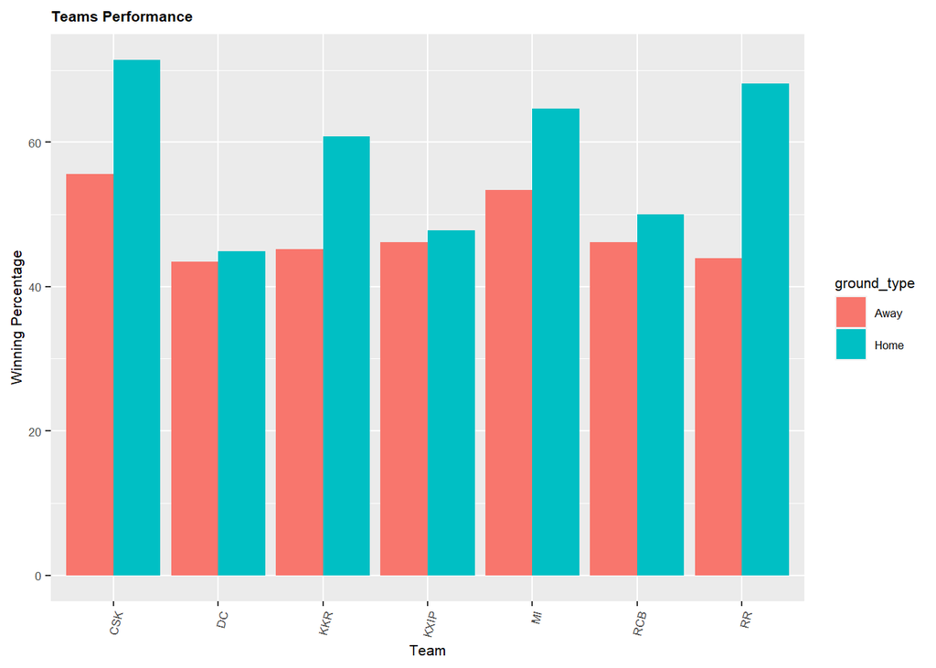

```r
DC<-merge(DC_match_played, DC_match_won, by ="ground_type")

DC<-DC %>%
  mutate(winning_perc = (total_win/total_match_played)*100,
         team = "DC")


team_performances<-rbind(CSK, DC,KKR,MI,KXIP,RCB,RR)

team_performances %>%
ggplot(aes(x = team, y =winning_perc,fill = ground_type))+
  geom_bar(stat = "identity", position = "dodge")+
  labs(title = "Teams Performance", x = "Team", y = "Winning Percentage")+
  theme(axis.text.x=element_text(angle=75, hjust=1), plot.title = element_text(size = 8, face = "bold"),text = element_text(size=8))
```

#### Inference: CSK and RR have the highest win percentage at their home grounds compared to other teams. CSK and MI have been the best performing teams away from their home grounds. This shows why they are one of the best franchises in the tournament because of their ability to maximise their home advantage and win almost 50 percentage of their away matches as well.

## Team Wise Performance Analysis

### Phase Wise Analysis of Teams

#### PowerPlay Analysis

```r
team_pp_runs = dataset %>%
  filter(over<=6, is_super_over == 0) %>%
  group_by(batting_team,match_id) %>%
  summarise(pp_runs = sum(total_runs)) %>%
  arrange(desc(pp_runs))
team_mean_pp_runs = team_pp_runs %>%
  group_by(batting_team) %>%
  summarise(avg_pp_runs = mean(pp_runs)) %>%
  arrange(desc(avg_pp_runs))
team_pp_wickets = dataset %>%
  filter(over<=6, is_super_over == 0) %>%
  group_by(bowling_team,match_id) %>%
  summarise(pp_wickets = sum(dismissal)) %>%
  arrange(desc(pp_wickets))
team_mean_pp_wickets = team_pp_wickets %>%
  group_by(bowling_team) %>%
  summarise(avg_pp_wickets = mean(pp_wickets)) %>%
  arrange(desc(avg_pp_wickets))
team_mean_pp_runs
```

```
## # A tibble: 11 x 2
##    batting_team avg_pp_runs
##    <chr>              <dbl>
##  1 GL                  51.8
##  2 KTK                 48.6
##  3 SRH                 47.2
##  4 KXIP                47.0
##  5 KKR                 46.9
##  6 DC                  46.5
##  7 CSK                 45.7
##  8 MI                  45.4
##  9 RR                  45
## 10 RCB                 44.9
## 11 RPS                 44.2
```

```r
team_mean_pp_wickets
```

```
## # A tibble: 11 x 2
##    bowling_team avg_pp_wickets
##    <chr>                 <dbl>
##  1 RR                     1.58
##  2 KTK                    1.57
##  3 GL                     1.57
##  4 CSK                    1.56
##  5 MI                     1.48
##  6 SRH                    1.44
##  7 RCB                    1.40
##  8 DC                     1.38
##  9 RPS                    1.36
## 10 KXIP                   1.35
## 11 KKR                    1.31
```

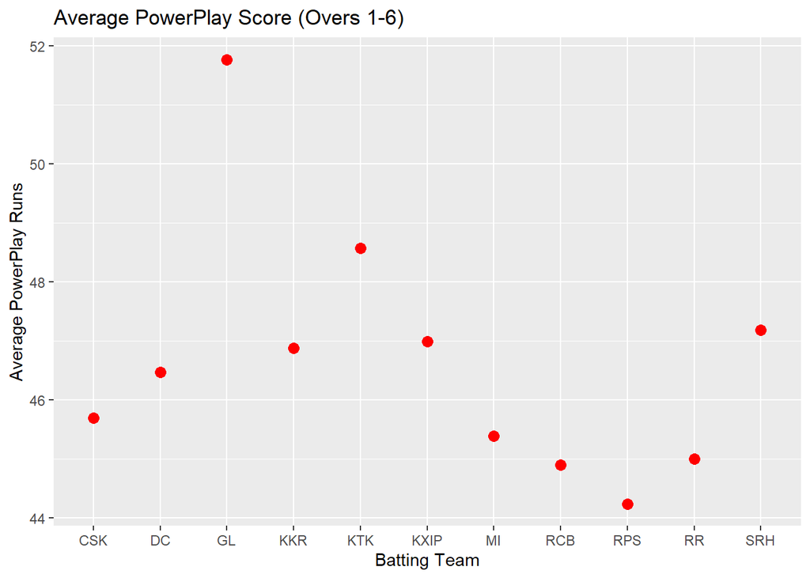

```r
ggplot(team_mean_pp_runs,aes(x=batting_team,y=avg_pp_runs))+
  geom_point(color="red",size=3)+labs(x="Batting Team",y="Average PowerPlay Runs",title="Average PowerPlay Score (Overs 1-6)")
```

#### Inference: GL and KTK have been the higher scoring teams in Powerplay across seasons.

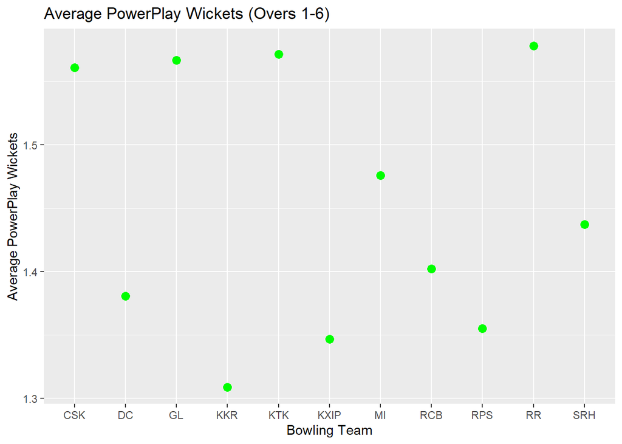

```r
ggplot(team_mean_pp_wickets,aes(x=bowling_team,y=avg_pp_wickets))+
  geom_point(color="green",size=3)+labs(x="Bowling Team",y="Average PowerPlay Wickets",title="Average PowerPlay Wickets (Overs 1-6)")
```

#### Inference: KTK,RR,CSK have picked the most wickets in Powerplay across seasons.

#### Middle Overs Analysis

```r
team_mo_runs = dataset %>%
  filter((over > 6 & over <=15), is_super_over == 0) %>%
  group_by(batting_team,match_id) %>%
  summarise(mo_runs = sum(total_runs)) %>%
  arrange(desc(mo_runs))
team_mean_mo_runs = team_mo_runs %>%
  group_by(batting_team) %>%
  summarise(avg_mo_runs = mean(mo_runs)) %>%
  arrange(desc(avg_mo_runs))
team_mo_wickets = dataset %>%
  filter((over > 6 & over <=15), is_super_over == 0) %>%
  group_by(bowling_team,match_id) %>%
  summarise(mo_wickets = sum(dismissal)) %>%
  arrange(desc(mo_wickets))
team_mean_mo_wickets = team_mo_wickets %>%
  group_by(bowling_team) %>%
  summarise(avg_mo_wickets = mean(mo_wickets)) %>%
  arrange(desc(avg_mo_wickets))
team_mean_mo_runs
```

```
## # A tibble: 11 x 2
##    batting_team avg_mo_runs
##    <chr>              <dbl>
##  1 GL                  71.5
##  2 KXIP                69.9
##  3 RR                  69.6
##  4 CSK                 69.0
##  5 RCB                 68.6
##  6 MI                  68.4
##  7 KKR                 67.5
##  8 DC                  67.4
##  9 SRH                 66.8
## 10 RPS                 61.7
## 11 KTK                 59.4
```

```r
team_mean_mo_wickets
```

```
## # A tibble: 11 x 2
##    bowling_team avg_mo_wickets
##    <chr>                 <dbl>
##  1 CSK                    2.37
##  2 MI                     2.35
##  3 SRH                    2.31
##  4 KKR                    2.28
##  5 RCB                    2.21
##  6 DC                     2.21
##  7 KXIP                   2.18
##  8 RR                     2.14
##  9 RPS                    2.12
## 10 KTK                    2
## 11 GL                     1.7
```

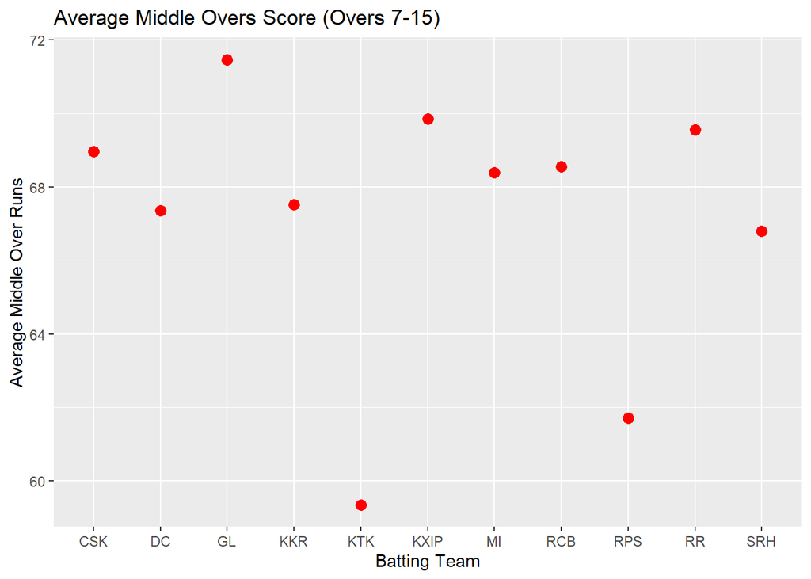

```r
ggplot(team_mean_mo_runs,aes(x=batting_team,y=avg_mo_runs))+
  geom_point(color="red",size=3)+labs(x="Batting Team",y="Average Middle Over Runs",title="Average Middle Overs Score (Overs 7-15)")
```

#### Inference: GL have the highest middle overs score across seasons

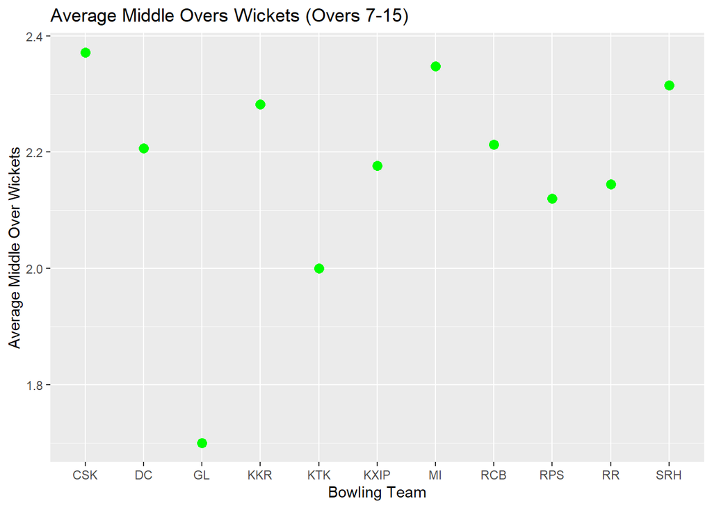

```r
ggplot(team_mean_mo_wickets,aes(x=bowling_team,y=avg_mo_wickets))+
  geom_point(color="green",size=3)+labs(x="Bowling Team",y="Average Middle Over Wickets",title="Average Middle Overs Wickets (Overs 7-15)")
```

#### Inference: CSK have picked the most wickets in middle overs across seasons.

#### Death Overs Analysis

```r
team_do_runs = dataset %>%
  filter((over > 15  & over <=20), is_super_over == 0) %>%
  group_by(batting_team,match_id) %>%
  summarise(do_runs = sum(total_runs)) %>%
  arrange(desc(do_runs))
team_mean_do_runs = team_do_runs %>%
  group_by(batting_team) %>%
  summarise(avg_do_runs = mean(do_runs)) %>%
  arrange(desc(avg_do_runs))
team_do_wickets = dataset %>%
  filter((over > 15 & over <=20), is_super_over == 0) %>%
  group_by(bowling_team,match_id) %>%
  summarise(do_wickets = sum(dismissal)) %>%
  arrange(desc(do_wickets))
team_mean_do_wickets = team_do_wickets %>%
  group_by(bowling_team) %>%
  summarise(avg_do_wickets = mean(do_wickets)) %>%
  arrange(desc(avg_do_wickets))
team_mean_do_runs
```

```
## # A tibble: 11 x 2
##    batting_team avg_do_runs
##    <chr>              <dbl>
##  1 RCB                 47.8
##  2 CSK                 47.5
##  3 MI                  47.5
##  4 SRH                 44.1
##  5 KXIP                44.0
##  6 KKR                 43.4
##  7 DC                  42.4
##  8 RPS                 42.1
##  9 RR                  41.6
## 10 GL                  41.4
## 11 KTK                 35.5
```

```r
team_mean_do_wickets
```

```
## # A tibble: 11 x 2
##    bowling_team avg_do_wickets
##    <chr>                 <dbl>
##  1 CSK                    2.45
##  2 DC                     2.41
##  3 SRH                    2.38
##  4 RCB                    2.33
##  5 MI                     2.32
##  6 KXIP                   2.28
##  7 KKR                    2.26
##  8 RPS                    2.26
##  9 RR                     2.22
## 10 KTK                    2
## 11 GL                     1.82
```

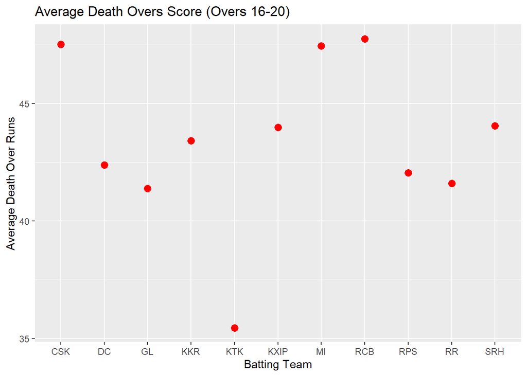

```r
ggplot(team_mean_do_runs,aes(x=batting_team,y=avg_do_runs))+
  geom_point(color="red",size=3)+labs(x="Batting Team",y="Average Death Over Runs",title="Average Death Overs Score (Overs 16-20)")
```

#### Inference: CSK, RCB and MI have scored the most runs in this phase across seasons

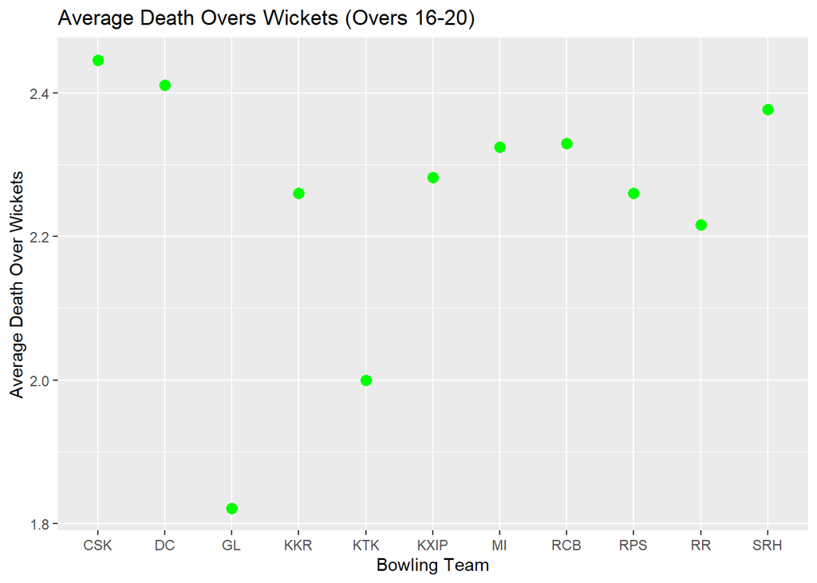

```r
ggplot(team_mean_do_wickets,aes(x=bowling_team,y=avg_do_wickets))+
  geom_point(color="green",size=3)+labs(x="Bowling Team",y="Average Death Over Wickets",title="Average Death Overs Wickets (Overs 16-20)")
```

#### Inference: CSK have picked the most wickets in this phase across seasons.

### Innings Wise Analysis of Teams

```r
team_inning1_score = dataset %>%
  filter(inning == 1, is_super_over == 0) %>%
  group_by(match_id,batting_team) %>%
  summarise(first_inning_score = sum(total_runs))
team_inning1_avg_score = team_inning1_score %>%
  group_by(batting_team) %>%
  summarise(first_inning_avg_score = mean(first_inning_score)) %>%
  arrange(desc(first_inning_avg_score))
team_inning2_score = dataset %>%
  filter(inning == 2, is_super_over == 0) %>%
  group_by(match_id,batting_team) %>%
  summarise(second_inning_score = sum(total_runs))
team_inning2_avg_score = team_inning2_score %>%
  group_by(batting_team) %>%
  summarise(second_inning_avg_score = mean(second_inning_score)) %>%
  arrange(desc(second_inning_avg_score))
team_inning1_avg_score
```

```
## # A tibble: 11 x 2
##    batting_team first_inning_avg_score
##    <chr>                         <dbl>
##  1 RCB                            168.
##  2 CSK                            167.
##  3 MI                             166.
##  4 KXIP                           162.
##  5 GL                             162.
##  6 SRH                            162.
##  7 KKR                            161.
##  8 RR                             159.
##  9 DC                             158.
## 10 RPS                            154.
## 11 KTK                            144.
```

```r
team_inning2_avg_score
```

```
## # A tibble: 11 x 2
##    batting_team second_inning_avg_score
##    <chr>                          <dbl>
##  1 GL                              162.
##  2 KXIP                            154.
##  3 CSK                             154.
##  4 MI                              151.
##  5 RR                              149
##  6 DC                              148.
##  7 KKR                             148.
##  8 SRH                             148.
##  9 RCB                             146.
## 10 RPS                             137.
## 11 KTK                             127.
```

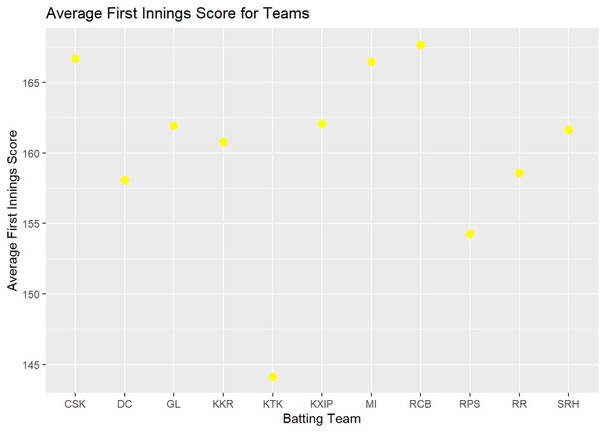

```r
ggplot(team_inning1_avg_score,aes(x=batting_team,y=first_inning_avg_score))+
  geom_point(color="yellow",size=3)+labs(x="Batting Team",y="Average First Innings Score",title="Average First Innings Score for Teams")
```

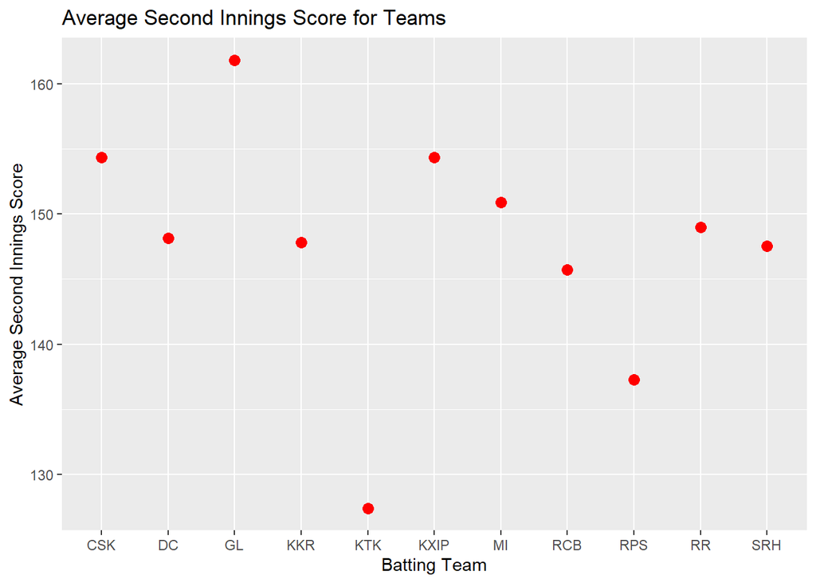

```r
ggplot(team_inning2_avg_score,aes(x=batting_team,y=second_inning_avg_score))+
  geom_point(color="red",size=3)+labs(x="Batting Team",y="Average Second Innings Score",title="Average Second Innings Score for Teams")
```

#### Inference: RCB and GL have the highest average runs scored in the first and second innings of the T20 match.

```r
team_inning1_wickets = dataset %>%
  filter(inning == 1, is_super_over == 0) %>%
  group_by(bowling_team,match_id) %>%
  summarise(first_inning_wickets = sum(dismissal))
team_inning1_avg_wickets = team_inning1_wickets %>%
  group_by(bowling_team) %>%
  summarise(first_inning_avg_wickets = mean(first_inning_wickets)) %>%
  arrange(desc(first_inning_avg_wickets))
team_inning2_wickets = dataset %>%
  filter(inning == 2, is_super_over == 0) %>%
  group_by(bowling_team,match_id) %>%
  summarise(second_inning_wickets = sum(dismissal))
team_inning2_avg_wickets = team_inning2_wickets %>%
  group_by(bowling_team) %>%
  summarise(second_inning_avg_wickets = mean(second_inning_wickets)) %>%
  arrange(desc(second_inning_avg_wickets))
team_inning1_avg_wickets
```

```
## # A tibble: 11 x 2
##    bowling_team first_inning_avg_wickets
##    <chr>                           <dbl>
##  1 CSK                              6.32
##  2 DC                               6.21
##  3 SRH                              6.18
##  4 KKR                              6.08
##  5 MI                               6.08
##  6 RR                               6.06
##  7 RCB                              6.03
##  8 RPS                              6
##  9 KXIP                             5.89
## 10 KTK                              5.86
## 11 GL                               5.75
```

```r
team_inning2_avg_wickets
```

```
## # A tibble: 11 x 2
##    bowling_team second_inning_avg_wickets
##    <chr>                            <dbl>
##  1 CSK                               6.24
##  2 MI                                6.09
##  3 SRH                               5.87
##  4 RCB                               5.49
##  5 RR                                5.46
##  6 KXIP                              5.37
##  7 DC                                5.26
##  8 KKR                               5.20
##  9 RPS                               5.17
## 10 KTK                               4.71
## 11 GL                                4.07
```

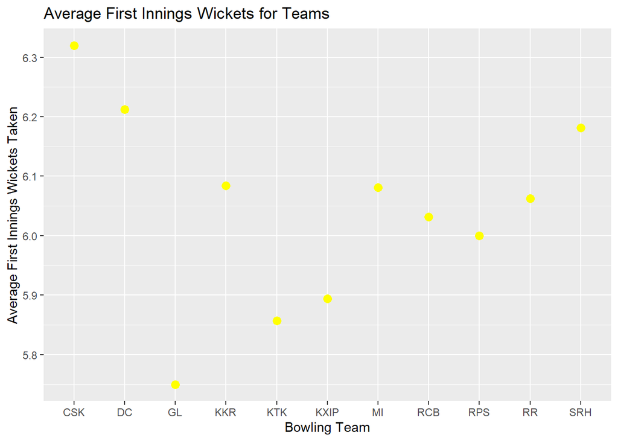

```r
ggplot(team_inning1_avg_wickets,aes(x=bowling_team,y=first_inning_avg_wickets))+
  geom_point(color="yellow",size=3)+labs(x="Bowling Team",y="Average First Innings Wickets Taken",title="Average First Innings Wickets for Teams")
```

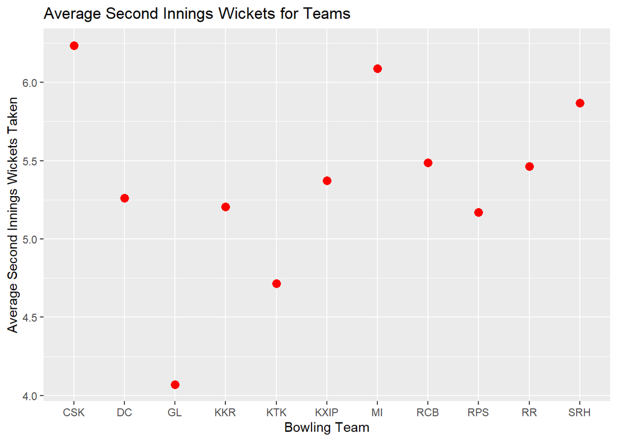

```r
ggplot(team_inning2_avg_wickets,aes(x=bowling_team,y=second_inning_avg_wickets))+
  geom_point(color="red",size=3)+labs(x="Bowling Team",y="Average Second Innings Wickets Taken",title="Average Second Innings Wickets for Teams")
```

#### Inference: CSK have picked up the most wickets in a T20 match across 12 seasons of the IPL.

### Season Wise Analysis of the 2 most successful franchises (CSK AND MI)

#### Overall Average Score of CSK AND MI

```r
csk_mi_season_score = dataset %>%
  filter(is_super_over == 0, (batting_team == "CSK" | batting_team == "MI")) %>%
  group_by(match_id,season,batting_team) %>%
  summarise(score = sum(total_runs))
csk_mi_season_avg_score = csk_mi_season_score %>%
  group_by(season,batting_team) %>%
  summarise(avg_score = mean(score))
csk_mi_season_avg_score
```

```
## # A tibble: 22 x 3
## # Groups:   season [12]
##    season batting_team avg_score
##     <int> <chr>            <dbl>
##  1   2008 CSK               158.
##  2   2008 MI                149.
##  3   2009 CSK               159.
##  4   2009 MI                146.
##  5   2010 CSK               162.
##  6   2010 MI                171.
##  7   2011 CSK               160
##  8   2011 MI                143
##  9   2012 CSK               157.
## 10   2012 MI                145.
## # ... with 12 more rows
```

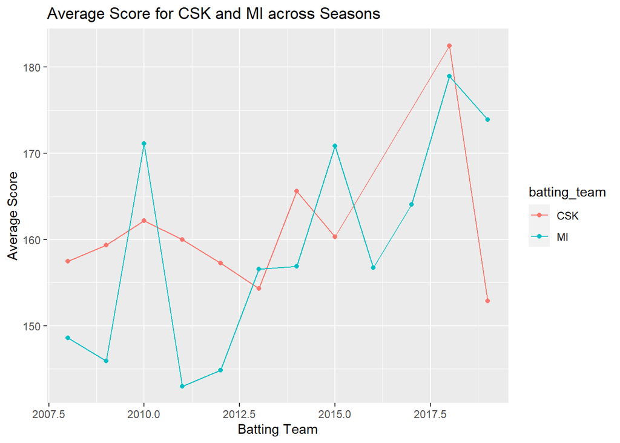

```r
ggplot(csk_mi_season_avg_score,aes(x = season, y=avg_score, color = batting_team))+geom_point()+
  geom_line()+labs(x="Batting Team",y="Average Score",title="Average Score for CSK and MI across Seasons")
```

#### Overall Average Wickets of CSK AND MI

```r
csk_mi_season_wickets = dataset %>%
  filter(is_super_over == 0, (bowling_team == "CSK" | bowling_team == "MI")) %>%
  group_by(match_id,season,bowling_team) %>%
  summarise(wickets = sum(dismissal))
csk_mi_season_avg_wickets = csk_mi_season_wickets %>%
  group_by(season,bowling_team) %>%
  summarise(avg_wickets= mean(wickets))
csk_mi_season_avg_wickets
```

```
## # A tibble: 22 x 3
## # Groups:   season [12]
##    season bowling_team avg_wickets
##     <int> <chr>              <dbl>
##  1   2008 CSK                 5.81
##  2   2008 MI                  6.71
##  3   2009 CSK                 6.5
##  4   2009 MI                  6.23
##  5   2010 CSK                 6.38
##  6   2010 MI                  6.31
##  7   2011 CSK                 5.69
##  8   2011 MI                  6.44
##  9   2012 CSK                 6
## 10   2012 MI                  6.24
## # ... with 12 more rows
```

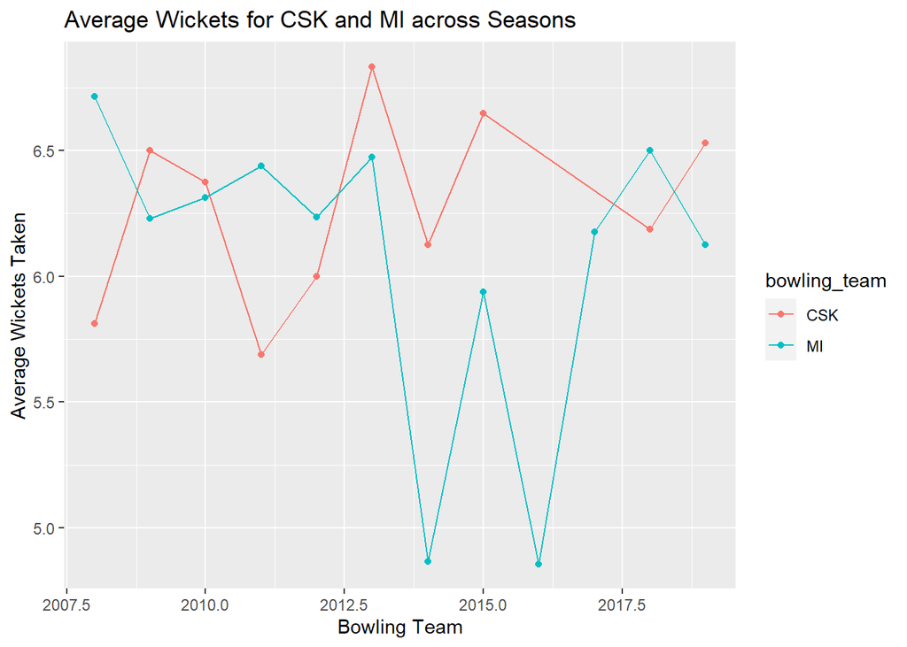

```r
ggplot(csk_mi_season_avg_wickets,aes(x = season, y=avg_wickets, color = bowling_team))+geom_point()+
  geom_line()+labs(x="Bowling Team",y="Average Wickets Taken",title="Average Wickets for CSK and MI across Seasons")
```

#### Inference: CSK are ahead of MI in terms of average wickets picked up in a match across the 12 seasons of the IPL.

## Venue Wise Performance Analysis

### Analysis is done only for the matches played in Indian Venues

```r
indian_venues = dataset %>%
  filter(city == "Mumbai" | city == "Chennai" | city == "Delhi" | city == "Kolkata" | city == "Hyderabad" | city == "Bangalore" | city == "Mohali" | city == "Jaipur" | city == "Pune" | city == "Kochi" | city == "Rajkot")

indian_venues = indian_venues %>%
  mutate(venue = replace(venue,venue == "Feroz Shah Kotla Ground", "Feroz Shah Kotla"))

indian_venues = indian_venues %>%
  mutate(venue = replace(venue,venue == "Dr DY Patil Sports Academy", "Wankhede Stadium"))

indian_venues = indian_venues %>%
  mutate(venue = replace(venue,venue == "Brabourne Stadium", "Wankhede Stadium"))

indian_venues = indian_venues %>%
  mutate(venue = replace(venue,venue == "Subrata Roy Sahara Stadium", "Maharashtra Cricket Association Stadium"))

indian_venues = indian_venues %>%
  mutate(venue = replace(venue,venue == "M. A. Chidambaram Stadium", "MA Chidambaram Stadium, Chepauk"))

indian_venues = indian_venues %>%
  mutate(venue = replace(venue,venue == "IS Bindra Stadium", "Punjab Cricket Association IS Bindra Stadium, Mohali"))

indian_venues = indian_venues %>%
  mutate(venue = replace(venue,venue == "Rajiv Gandhi Intl. Cricket Stadium", "Rajiv Gandhi International Stadium, Uppal"))


unique(indian_venues$venue)
```

```
##  [1] "Rajiv Gandhi International Stadium, Uppal"
##  [2] "Maharashtra Cricket Association Stadium"
##  [3] "Saurashtra Cricket Association Stadium"
##  [4] "M Chinnaswamy Stadium"
##  [5] "Wankhede Stadium"
##  [6] "Eden Gardens"
##  [7] "Feroz Shah Kotla"
##  [8] "Sawai Mansingh Stadium"
##  [9] "MA Chidambaram Stadium, Chepauk"
## [10] "Nehru Stadium"
## [11] "Punjab Cricket Association IS Bindra Stadium, Mohali"
```

### Toss Decisions taken at Venues

```r
indian_venues_played = indian_venues %>%
  group_by(venue) %>%
  summarise(matches_played = n_distinct(match_id)) %>%
  arrange(desc(matches_played))
indian_venues_toss_field = indian_venues %>%
  filter(toss_winner == winner, is_super_over == 0, toss_decision == "field") %>%
  group_by(venue,toss_decision) %>%
  summarise(matches_won = n_distinct(match_id)) %>%
  arrange(desc(matches_won))
indian_venues_toss_bat = indian_venues %>%
  filter(toss_winner == winner, is_super_over == 0, toss_decision == "bat") %>%
  group_by(venue,toss_decision) %>%
  summarise(matches_won = n_distinct(match_id)) %>%
  arrange(desc(matches_won))
indian_venues_played
```

```
## # A tibble: 11 x 2
##    venue                                                matches_played
##    <chr>                                                         <int>
##  1 Wankhede Stadium                                                101
##  2 Eden Gardens                                                     77
##  3 Feroz Shah Kotla                                                 74
##  4 M Chinnaswamy Stadium                                            66
##  5 Rajiv Gandhi International Stadium, Uppal                        64
##  6 MA Chidambaram Stadium, Chepauk                                  57
##  7 Sawai Mansingh Stadium                                           47
##  8 Maharashtra Cricket Association Stadium                          38
##  9 Punjab Cricket Association IS Bindra Stadium, Mohali             10
## 10 Saurashtra Cricket Association Stadium                           10
## 11 Nehru Stadium                                                     5
```

```r
indian_venues_toss_field
```

```
## # A tibble: 11 x 3
## # Groups:   venue [11]
##    venue                                               toss_decision matches_won
##    <chr>                                               <chr>               <int>
##  1 Wankhede Stadium                                    field                  35
##  2 M Chinnaswamy Stadium                               field                  32
##  3 Eden Gardens                                        field                  31
##  4 Feroz Shah Kotla                                    field                  23
##  5 Sawai Mansingh Stadium                              field                  19
##  6 Rajiv Gandhi International Stadium, Uppal           field                  15
##  7 Maharashtra Cricket Association Stadium             field                  13
##  8 MA Chidambaram Stadium, Chepauk                     field                   8
##  9 Punjab Cricket Association IS Bindra Stadium, Moha~ field                   6
## 10 Saurashtra Cricket Association Stadium              field                   4
## 11 Nehru Stadium                                       field                   1
```

```r
indian_venues_toss_bat
```

```
## # A tibble: 10 x 3
## # Groups:   venue [10]
##    venue                                               toss_decision matches_won
##    <chr>                                               <chr>               <int>
##  1 MA Chidambaram Stadium, Chepauk                     bat                    22
##  2 Wankhede Stadium                                    bat                    18
##  3 Feroz Shah Kotla                                    bat                    15
##  4 Eden Gardens                                        bat                    12
##  5 Maharashtra Cricket Association Stadium             bat                    10
##  6 Rajiv Gandhi International Stadium, Uppal           bat                     6
##  7 Sawai Mansingh Stadium                              bat                     6
##  8 M Chinnaswamy Stadium                               bat                     4
##  9 Nehru Stadium                                       bat                     1
## 10 Punjab Cricket Association IS Bindra Stadium, Moha~ bat                     1
```

#### Inference: Wankhede and Chinnaswamy Stadiums in Mumbai and Bangalore are better chasing grounds while MA Chidambaram Stadium are in Chennai is a better batting defending grounds.

### Phase Wise Analaysis

#### Average Powerplay Score across Venues

```r
venue_pp_score = indian_venues %>%
  filter(is_super_over == 0, over<=6, winner == batting_team) %>%
  group_by(match_id,batting_team,venue,inning) %>%
  summarise(pp_score = sum(total_runs)) %>%
  arrange(desc(pp_score))
venue_avg_pp_score = venue_pp_score %>%
  group_by(venue) %>%
  summarise(avg_pp_score = mean(pp_score)) %>%
  arrange(desc(avg_pp_score))
venue_avg_pp_score
```

```
## # A tibble: 11 x 2
##    venue                                                avg_pp_score
##    <chr>                                                       <dbl>
##  1 Saurashtra Cricket Association Stadium                       60.7
##  2 Punjab Cricket Association IS Bindra Stadium, Mohali         57.6
##  3 Feroz Shah Kotla                                             50.5
##  4 M Chinnaswamy Stadium                                        49.5
##  5 Rajiv Gandhi International Stadium, Uppal                    49.4
##  6 Eden Gardens                                                 48.9
##  7 Wankhede Stadium                                             48.8
##  8 Maharashtra Cricket Association Stadium                      48.2
##  9 Sawai Mansingh Stadium                                       48.0
## 10 MA Chidambaram Stadium, Chepauk                              48.0
## 11 Nehru Stadium                                                37.2
```

```
## geom_path: Each group consists of only one observation. Do you need to adjust
## the group aesthetic?
```

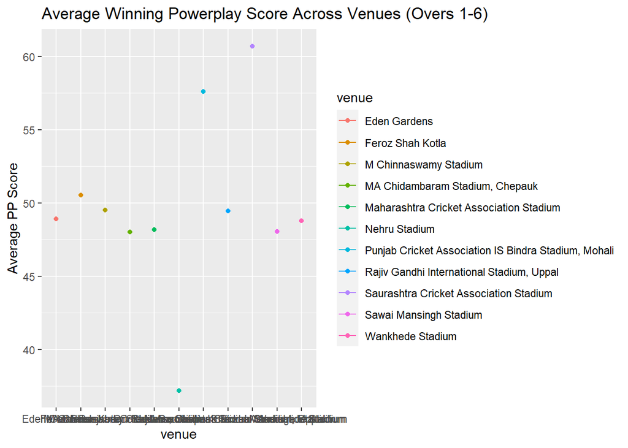

```r
ggplot(venue_avg_pp_score,aes(x = venue, y=avg_pp_score, color = venue))+geom_point()+
  geom_line()+labs(y="Average PP Score",title="Average Winning Powerplay Score Across Venues (Overs 1-6)")
```

#### Inference: Rajkot which is the home ground of GL is the highest scoring ground in the first 6 overs while Kochi which is the home ground of KTK is the least scoring ground in powerplay.

#### Average Middle Overs Score across Venues

```r
venue_mo_score = indian_venues %>%
  filter(is_super_over == 0, over>6 & over<=15, winner == batting_team) %>%
  group_by(match_id,batting_team,venue,inning) %>%
  summarise(mo_score = sum(total_runs)) %>%
  arrange(desc(mo_score))
venue_avg_mo_score = venue_mo_score %>%
  group_by(venue) %>%
  summarise(avg_mo_score = mean(mo_score)) %>%
  arrange(desc(avg_mo_score))
venue_avg_mo_score
```

```
## # A tibble: 11 x 2
##    venue                                                avg_mo_score
##    <chr>                                                       <dbl>
##  1 Punjab Cricket Association IS Bindra Stadium, Mohali         84.1
##  2 M Chinnaswamy Stadium                                        75.1
##  3 Saurashtra Cricket Association Stadium                       74.8
##  4 Feroz Shah Kotla                                             73.7
##  5 Sawai Mansingh Stadium                                       73.7
##  6 Wankhede Stadium                                             72.6
##  7 Eden Gardens                                                 71.3
##  8 Rajiv Gandhi International Stadium, Uppal                    71.3
##  9 MA Chidambaram Stadium, Chepauk                              70.8
## 10 Nehru Stadium                                                69.8
## 11 Maharashtra Cricket Association Stadium                      67.4
```

```
## geom_path: Each group consists of only one observation. Do you need to adjust
## the group aesthetic?
```

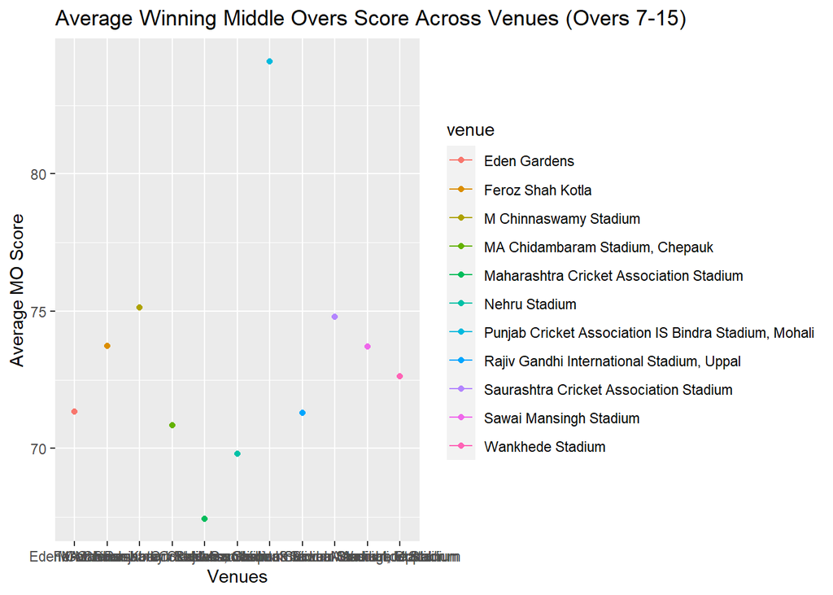

```r
ggplot(venue_avg_mo_score,aes(x = venue, y=avg_mo_score, color = venue))+geom_point()+
  geom_line()+labs(x="Venues",y="Average MO Score",title="Average Winning Middle Overs Score Across Venues (Overs 7-15)")
```

#### Average Death Overs Score Across Venues

```r
venue_do_score = indian_venues %>%
  filter(is_super_over == 0, over>15 & over<=20, winner == batting_team) %>%
  group_by(match_id,batting_team,venue,inning) %>%
  summarise(do_score = sum(total_runs)) %>%
  arrange(desc(do_score))
venue_avg_do_score = venue_do_score %>%
  group_by(venue) %>%
  summarise(avg_do_score = mean(do_score)) %>%
  arrange(desc(avg_do_score))
venue_avg_do_score
```

```
## # A tibble: 11 x 2
##    venue                                                avg_do_score
##    <chr>                                                       <dbl>
##  1 M Chinnaswamy Stadium                                        51.3
##  2 Nehru Stadium                                                51
##  3 Wankhede Stadium                                             50.6
##  4 Maharashtra Cricket Association Stadium                      48.7
##  5 MA Chidambaram Stadium, Chepauk                              47.4
##  6 Feroz Shah Kotla                                             46.1
##  7 Eden Gardens                                                 44.8
##  8 Rajiv Gandhi International Stadium, Uppal                    44.1
##  9 Sawai Mansingh Stadium                                       42.8
## 10 Saurashtra Cricket Association Stadium                       42.8
## 11 Punjab Cricket Association IS Bindra Stadium, Mohali         40.7
```

```
## geom_path: Each group consists of only one observation. Do you need to adjust
## the group aesthetic?
```

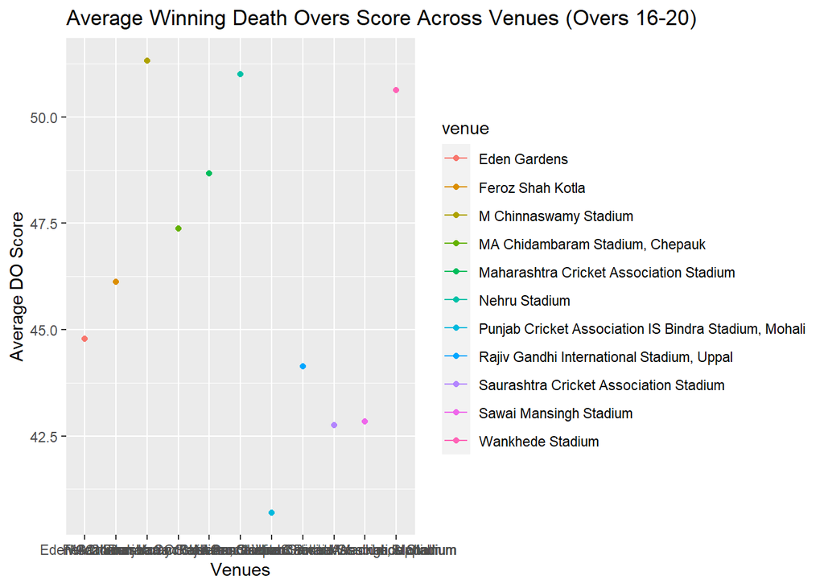

```r
ggplot(venue_avg_do_score,aes(x = venue, y=avg_do_score, color = venue))+geom_point()+
  geom_line()+labs(x="Venues",y="Average DO Score",title="Average Winning Death Overs Score Across Venues (Overs 16-20)")
```

### Innings Wise Analysis

#### Average Winning Score (1st Innings) across Venues

```r
venue_winning_inning1_score = indian_venues %>%
  filter(inning == 1, is_super_over == 0, winner == batting_team) %>%
  group_by(match_id,batting_team,venue) %>%
  summarise(winning_inning1_score = sum(total_runs))
venue_winning_avg_inning1_score = venue_winning_inning1_score %>%
  group_by(venue) %>%
  summarise(avg_winning_inning1_score = mean(winning_inning1_score))
venue_winning_avg_inning1_score
```

```
## # A tibble: 11 x 2
##    venue                                                avg_winning_inning1_sco~
##    <chr>                                                                   <dbl>
##  1 Eden Gardens                                                             175.
##  2 Feroz Shah Kotla                                                         183.
##  3 M Chinnaswamy Stadium                                                    188.
##  4 MA Chidambaram Stadium, Chepauk                                          173.
##  5 Maharashtra Cricket Association Stadium                                  169.
##  6 Nehru Stadium                                                            147.
##  7 Punjab Cricket Association IS Bindra Stadium, Mohali                     191
##  8 Rajiv Gandhi International Stadium, Uppal                                174.
##  9 Saurashtra Cricket Association Stadium                                   185
## 10 Sawai Mansingh Stadium                                                   176.
## 11 Wankhede Stadium                                                         178.
```

```
## geom_path: Each group consists of only one observation. Do you need to adjust
## the group aesthetic?
```

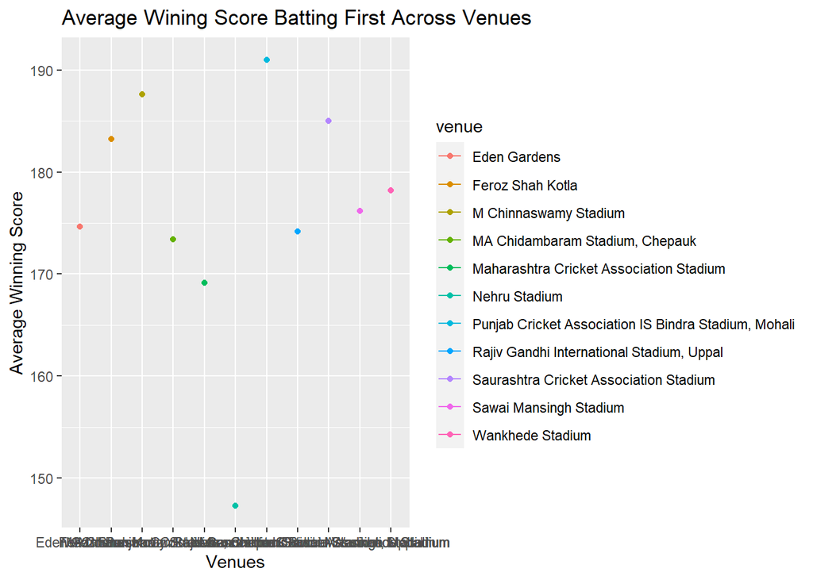

```r
ggplot(venue_winning_avg_inning1_score,aes(x = venue, y=avg_winning_inning1_score, color = venue))+geom_point()+
  geom_line()+labs(x="Venues",y="Average Winning Score",title="Average Wining Score Batting First Across Venues")
```

#### Inference: Mohali has the highest average winning score in the 1st Innings while Kochi has the lowest in the 1st Innings.

#### Average Chasing Score (2nd Innings) across Venues

```r
venue_winning_inning2_score = indian_venues %>%
  filter(inning == 2, is_super_over == 0, winner == batting_team) %>%
  group_by(match_id,batting_team,venue) %>%
  summarise(winning_inning2_score = sum(total_runs))
venue_winning_avg_inning2_score = venue_winning_inning2_score %>%
  group_by(venue) %>%
  summarise(avg_winning_inning2_score = mean(winning_inning2_score))
venue_winning_avg_inning2_score
```

```
## # A tibble: 11 x 2
##    venue                                                avg_winning_inning2_sco~
##    <chr>                                                                   <dbl>
##  1 Eden Gardens                                                             150.
##  2 Feroz Shah Kotla                                                         150.
##  3 M Chinnaswamy Stadium                                                    153.
##  4 MA Chidambaram Stadium, Chepauk                                          153.
##  5 Maharashtra Cricket Association Stadium                                  155
##  6 Nehru Stadium                                                            148.
##  7 Punjab Cricket Association IS Bindra Stadium, Mohali                     177.
##  8 Rajiv Gandhi International Stadium, Uppal                                149
##  9 Saurashtra Cricket Association Stadium                                   163.
## 10 Sawai Mansingh Stadium                                                   154.
## 11 Wankhede Stadium                                                         156.
```

```
## geom_path: Each group consists of only one observation. Do you need to adjust
## the group aesthetic?
```

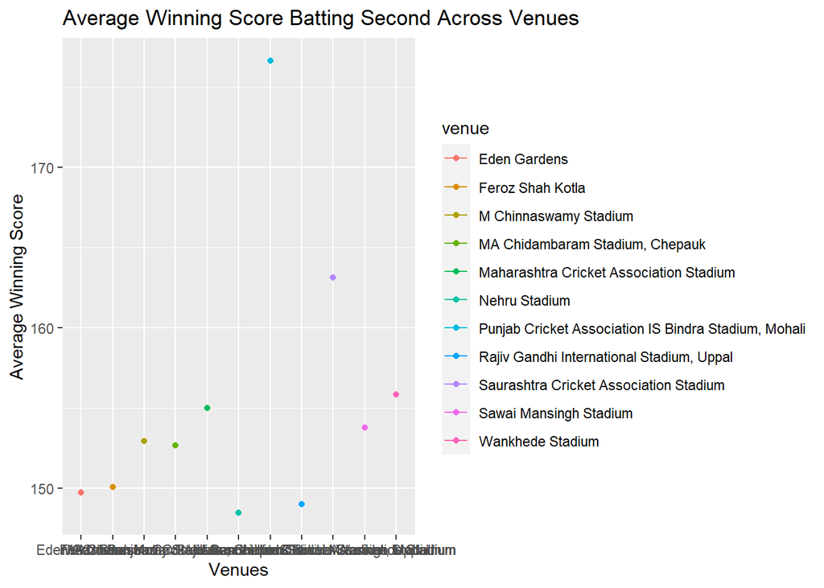

```r
ggplot(venue_winning_avg_inning2_score,aes(x = venue, y=avg_winning_inning2_score, color = venue))+geom_point()+
  geom_line()+labs(x="Venues",y="Average Winning Score",title="Average Winning Score Batting Second Across Venues")
```

#### Inference: Mohali is a high scoring chasing ground while Kolkata, Delhi, Kochi are low scoring chasing grounds.

### Season Wise Analysis of the 2 most successful franchises (CSK AND MI)

#### Comparing Chepauk Stadium and Wankhede Stadium (Home Grounds of CSK and MI)

```r
csk_mi_venue_season_score = indian_venues %>%
  filter(is_super_over == 0, venue == "MA Chidambaram Stadium, Chepauk" | venue == "Wankhede Stadium",winner == batting_team) %>%
  group_by(match_id,season,batting_team,venue,inning) %>%
  summarise(first_inning_score = sum(total_runs))
csk_mi_venue_avg_season_score = csk_mi_venue_season_score %>%
  group_by(season,venue) %>%
  summarise(avg_inning1_score = mean(first_inning_score))
csk_mi_venue_avg_season_score
```

```
## # A tibble: 19 x 3
## # Groups:   season [11]
##    season venue                           avg_inning1_score
##     <int> <chr>                                       <dbl>
##  1   2008 MA Chidambaram Stadium, Chepauk              171.
##  2   2008 Wankhede Stadium                             147.
##  3   2010 MA Chidambaram Stadium, Chepauk              165
##  4   2010 Wankhede Stadium                             165.
##  5   2011 MA Chidambaram Stadium, Chepauk              168.
##  6   2011 Wankhede Stadium                             151.
##  7   2012 MA Chidambaram Stadium, Chepauk              162.
##  8   2012 Wankhede Stadium                             142.
##  9   2013 MA Chidambaram Stadium, Chepauk              172.
## 10   2013 Wankhede Stadium                             177.
## 11   2014 Wankhede Stadium                             184.
## 12   2015 MA Chidambaram Stadium, Chepauk              164.
## 13   2015 Wankhede Stadium                             186.
## 14   2016 Wankhede Stadium                             156.
## 15   2017 Wankhede Stadium                             172.
## 16   2018 MA Chidambaram Stadium, Chepauk              212
## 17   2018 Wankhede Stadium                             181.
## 18   2019 MA Chidambaram Stadium, Chepauk              152.
## 19   2019 Wankhede Stadium                             162.
```

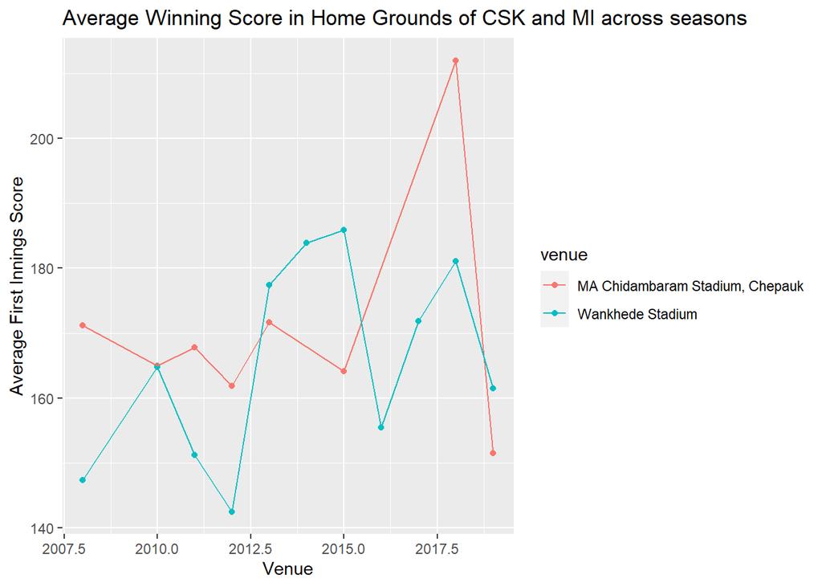

```r
ggplot(csk_mi_venue_avg_season_score,aes(x = season, y=avg_inning1_score, color = venue))+geom_point()+
  geom_line()+labs(x="Venue",y="Average First Innings Score",title="Average Winning Score in Home Grounds of CSK and MI across seasons")
```

## Conclusion and Future Work

### Based on the above conclusions drawn from venue wise and team wise performance analysis, teams can identify the phases in the game where they are lagging behind and plug those holes by picking appropriate players in the auctions according to their shortcomings and home ground conditions. This will improve their performance and chances of winning the championship.

### Appropriate Player based analayis can be carried out on the same dataset in future to identify the best players according to the roles in different phases and venue conditions of the game. Hence, an effective model could be built for the teams to pick the right players in the upcoming auctions and assign roles and startegies to players.

## Player Performance Analysis

### Create Primary Datasets for Players

```r
mat_ds <- matches %>%
  select(
    match_id = id,
    season,
    city,
    team1,
    team2,
    toss_winner,
    toss_dec = toss_decision,
    winner,
    pom = player_of_match,
    venue
  )

del_ds <- deliveries %>%
  select(
    inning,
    match_id,
    over,
    ball,
    batsman,
    bowler,
    runs = batsman_runs,
    bat_team = batting_team,
    bowl_team = bowling_team,
    total_runs,
    dismissal_kind
  ) %>%
  gather(role, player, batsman:bowler) %>%
  mutate(role=as.factor(role))
```

### 1st Objective - Building a model to rank players by their playing calibre:

#### A player value depends upon

#### • his ability to score quick runs (highest strike rates) and bowl economically (lowest economy rates)

#### • his contribution made to the runs scored by the team and the wickets dismissed by the team in matches that have been both won and lost by his team

#### • his ability to score quick runs against top bowlers (we will consider top 20 bowlers by their economy rate) and to bowl economically against top batsmen (we will consider top 20 batsmen by their strike rates).

#### • all players are rated as a batsman and as a bowler irrespective of their actual or primary domain.

#### Hence, the nomenclature, “batsman” or “bowler” in the model building refers to all players.

### TOP_RATE_PLAYERS:

#### Order of players with best batting striking rates & bowling economy rates

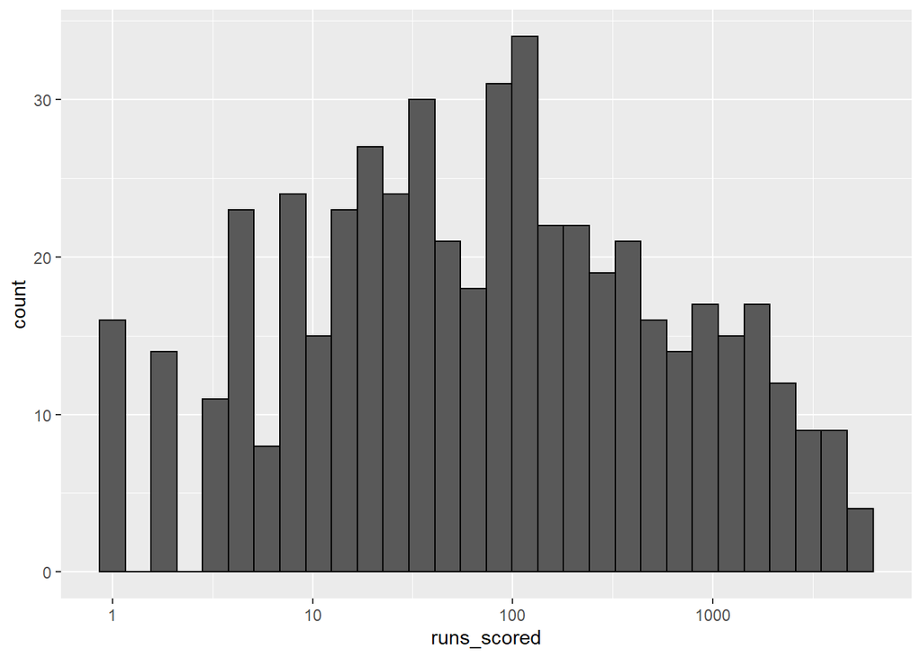

```r
# Distribution of runs scored by batsmen
del_ds %>%
  filter(role == "batsman") %>%
  group_by(player) %>%
  summarize(runs_scored = sum(runs)) %>%
  mutate(runs_scored = runs_scored + 1) %>%
  ggplot(aes(runs_scored)) +
  geom_histogram(aes(), bins=30, colour="black") +
  scale_x_log10()
```

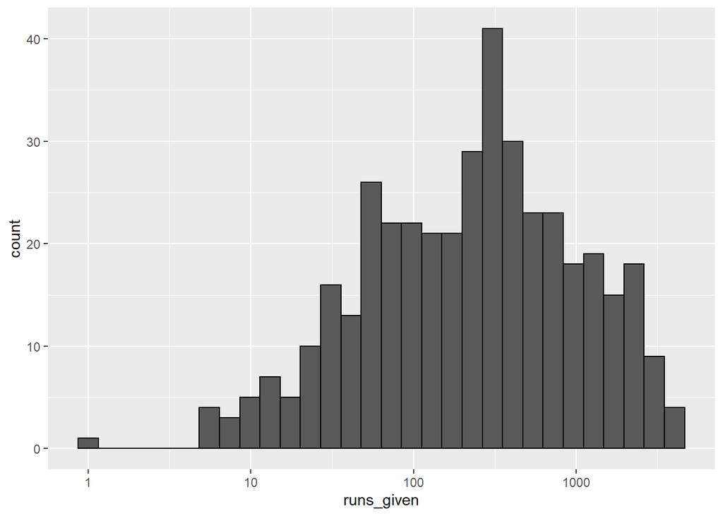

```r
# Distribution of runs given by bowlers
del_ds %>%
  filter(role == "bowler") %>%
  group_by(player) %>%
  summarize(runs_given = sum(runs)) %>%
  mutate(runs_given = runs_given + 1) %>%
  ggplot(aes(runs_given)) +
  geom_histogram(aes(), bins=30, colour="black") +
  scale_x_log10()
```

```r
# Batsmen average & median number of balls and runs
batsmen_avgs <- del_ds %>%
  filter(role == "batsman") %>%
  group_by(player) %>%
  summarize(tot_balls = n(), tot_runs = sum(runs)) %>%
  summarize (
    avg_balls = mean(tot_balls),
    median_balls = median(tot_balls),
    avg_runs = mean(tot_runs),
    median_runs = median(tot_runs),
    max(tot_runs),
    min(tot_runs),
    max(tot_balls),
    min(tot_balls)
  )
t(as.matrix(batsmen_avgs))
```

```
##                     [,1]
## avg_balls       347.0504
## median_balls     70.5000
## avg_runs        432.7248
## median_runs      74.0000
## max(tot_runs)  5434.0000
## min(tot_runs)     0.0000
## max(tot_balls) 4211.0000
## min(tot_balls)    1.0000
```

```r
# Bowler average & median number of balls and runs
bowler_avgs <- del_ds %>%
  filter(role == "bowler") %>%
  group_by(player) %>%
  summarize(tot_balls = n(), tot_runs = sum(runs)) %>%
  summarize (
    avg_balls = mean(tot_balls),
    median_balls = median(tot_balls),
    avg_runs = mean(tot_runs),
    median_runs = median(tot_runs),
    max(tot_runs),
    min(tot_runs),
    max(tot_balls),
    min(tot_balls)
  )
t(as.matrix(bowler_avgs))
```

```
##                     [,1]
## avg_balls       442.1679
## median_balls    196.0000
## avg_runs        551.3235
## median_runs     254.0000
## max(tot_runs)  4022.0000
## min(tot_runs)     0.0000
## max(tot_balls) 3451.0000
## min(tot_balls)    1.0000
```

### Inference: Now, we will calculate the strike rates for batsmen and economy rates for bowlers using regularization technique. We have earlier seen that the players with highest batting strike rates and best economy rates are not well known for their skills in respective domains (batting or bowling). However, they ended best because of the fact that they played very few balls, resulting in best rates. In order to neutralize this effect, we use penalties to calculate revised batting strike rates or bowling economy rates. From the batsmen and bowler statistics generated above we see the median values are much smaller than the average values. Hence, we use median values as the penalty terms to regularize as this will not effect much the rates of regular, known players in respective domains but will reduce the effects for the players who had batted/ bowled a very few balls. Then we take a look again at the players with highest batting strike rates and lowest economy rates.

```r
# Top players with strike rates & economy rates after regularisation using median runs
# and median balls
str_rates <- del_ds %>%
  filter(role == "batsman") %>%
  group_by(player) %>%
  summarize(reg_str_rate = (sum(runs) + batsmen_avgs$median_runs) / (n() +
      batsmen_avgs$median_balls)) %>%
  arrange(desc(reg_str_rate))
str_rates %>%
  head(20)
```

```
## # A tibble: 20 x 2
##    player         reg_str_rate
##    <chr>                 <dbl>
##  1 AD Russell             1.74
##  2 SP Narine              1.59
##  3 RR Pant                1.59
##  4 GJ Maxwell             1.52
##  5 M Ali                  1.52
##  6 J Bairstow             1.49
##  7 HH Pandya              1.48
##  8 AB de Villiers         1.48
##  9 V Sehwag               1.47
## 10 JC Buttler             1.47
## 11 CH Morris              1.45
## 12 BCJ Cutting            1.45
## 13 CH Gayle               1.45
## 14 K Gowtham              1.42
## 15 KA Pollard             1.40
## 16 KH Pandya              1.40
## 17 N Pooran               1.39
## 18 DA Warner              1.39
## 19 YK Pathan              1.38
## 20 CR Brathwaite          1.38
```

```r
eco_rates <- del_ds %>%
  filter(role == "bowler") %>%
  group_by(player) %>%
  summarize(reg_eco_rate = (sum(runs) + bowler_avgs$median_runs) /
(n() + bowler_avgs$median_balls)) %>%
  arrange(reg_eco_rate)
eco_rates %>%
  head(20)
```

```
## # A tibble: 20 x 2
##    player           reg_eco_rate
##    <chr>                   <dbl>
##  1 DW Steyn                 1.06
##  2 M Muralitharan           1.07
##  3 R Ashwin                 1.08
##  4 Sohail Tanvir            1.08
##  5 A Kumble                 1.09
##  6 SL Malinga               1.10
##  7 SP Narine                1.10
##  8 SW Tait                  1.11
##  9 DP Nannes                1.12
## 10 MA Starc                 1.13
## 11 Rashid Khan              1.13
## 12 Harbhajan Singh          1.13
## 13 WD Parnell               1.14
## 14 RE van der Merwe         1.14
## 15 J Botha                  1.14
## 16 B Kumar                  1.14
## 17 DL Vettori               1.15
## 18 FH Edwards               1.15
## 19 DE Bollinger             1.15
## 20 A Chandila               1.15
```

### Inference: Now as expected we can see that the top players for batting strike rates and bowling economy rates are alltop, regular players in the respective domains of batting and bowling. Next, using the regularized strike rates and economy rates, we construct top rated players, Naturally, we can expect all players who are in batsmen list may not figure in bowler list, and vice versa. This will reintroduce NAs when we try to combine strike rates and economy rates to arrive at player values. We use a similar technique as regularization to replace these NAs. For those players who have never batted, we will assume them to score minimum runs in maximum balls. Hence, we will use median runs and average balls for replacing NAs. Similarly, for players who have never bowled, we will assume them to give away more runs in less balls. Hence, we will use average runs and median balls for replacing NAs. With the above approach, let us see who are our top rated players.

```r
# Top rate players based on strike rates & economy rates
top_rate_players <- str_rates %>%
  full_join(eco_rates, by = "player") %>%
  mutate(reg_str_rate = replace_na(
    reg_str_rate,
    batsmen_avgs$median_runs / batsmen_avgs$avg_balls
  )) %>%
  mutate(reg_eco_rate = replace_na(reg_eco_rate, bowler_avgs$avg_runs /
                                     bowler_avgs$median_balls)) %>%
  mutate(player_value = 100 * (reg_str_rate + 1 / reg_eco_rate))

top_rate_players %>%
  arrange(desc(player_value)) %>%
  select(player, player_value) %>%
  mutate(rank = row_number()) %>%
  head(50) %>%
  knitr::kable()
```

| player | player_value | rank |
| --- | --- | --- |
| SP Narine | 249.8296 | 1 |
| AD Russell | 245.4557 | 2 |
| M Ali | 234.0577 | 3 |
| CH Gayle | 228.1677 | 4 |
| GJ Maxwell | 225.5855 | 5 |
| KH Pandya | 225.0858 | 6 |
| CH Morris | 223.7291 | 7 |
| YK Pathan | 222.7373 | 8 |
| Rashid Khan | 221.7830 | 9 |
| HH Pandya | 218.6351 | 10 |
| SR Watson | 218.4355 | 11 |
| Harbhajan Singh | 217.4723 | 12 |
| K Gowtham | 217.2212 | 13 |
| SK Raina | 216.8137 | 14 |
| KK Cooper | 216.5388 | 15 |
| Mohammad Nabi | 216.3234 | 16 |
| KA Pollard | 216.2749 | 17 |
| BCJ Cutting | 216.2111 | 18 |
| V Sehwag | 215.7857 | 19 |
| MF Maharoof | 214.2093 | 20 |
| JA Morkel | 213.8583 | 21 |
| Shahid Afridi | 213.4270 | 22 |
| Bipul Sharma | 212.1187 | 23 |
| SN Khan | 211.7002 | 24 |
| KP Pietersen | 211.6698 | 25 |
| CR Brathwaite | 211.4528 | 26 |
| RN ten Doeschate | 211.2386 | 27 |
| Ankit Sharma | 211.1351 | 28 |
| KS Williamson | 209.8720 | 29 |
| ST Jayasuriya | 209.8612 | 30 |
| AC Gilchrist | 209.3954 | 31 |
| Umar Gul | 209.3522 | 32 |
| DL Chahar | 207.8779 | 33 |
| RA Tripathi | 207.6624 | 34 |
| N Rana | 207.6340 | 35 |
| RG Sharma | 207.5759 | 36 |
| LJ Wright | 207.2914 | 37 |
| Yuvraj Singh | 206.3828 | 38 |
| M Morkel | 206.2108 | 39 |
| JP Duminy | 205.7658 | 40 |
| JD Ryder | 205.6850 | 41 |
| A Ashish Reddy | 205.6455 | 42 |
| STR Binny | 204.9562 | 43 |
| SM Pollock | 204.8870 | 44 |
| V Kohli | 204.3044 | 45 |
| S Curran | 204.2641 | 46 |
| Shakib Al Hasan | 204.2299 | 47 |
| BA Stokes | 204.0291 | 48 |
| A Symonds | 203.9560 | 49 |
| C de Grandhomme | 203.9522 | 50 |

### Inference: As we could see the list includes some match winning top all round players who are big hitters with high strike rates and bowl tight overs

### TOP_CONTRI_PLAYERS:

### Order of players with best number of highest contributions in won & lost matches

```r
# Which teams have won which matches and lost which matches
# Which matches which teams have won
won_t1 <- mat_ds %>%
filter(winner != "") %>%
filter(as.character(winner) == as.character(team1)) %>%
select(match_id, team = team1)
won_t2 <- mat_ds %>%
filter(winner != "") %>%
filter(as.character(winner) == as.character(team2)) %>%
select(match_id, team = team2)
won_matches <- won_t1 %>%
bind_rows(won_t2)
# Which matches which teams have lost
lost_t1 <- mat_ds %>%
filter(winner != "") %>%
filter(as.character(winner) != as.character(team1)) %>%
select(match_id, team = team1, winner)
lost_t2 <- mat_ds %>%
filter(winner != "") %>%
filter(as.character(winner) != as.character(team2)) %>%
select(match_id, team = team2, winner)
lost_matches <- lost_t1 %>%
bind_rows(lost_t2)
```

```r
# Batsmen score contribution in won matches
# Top scorer for winning sides
batsman_contr_w <- del_ds %>%
full_join(won_matches, by = "match_id") %>%
filter(role == "batsman" & bat_team == team) %>%
group_by(match_id, player) %>%
summarize(batsman_score = sum(runs)) %>%
top_n(1, batsman_score) %>%
full_join(won_matches, by = "match_id")
batsman_contr_w
```

```
## # A tibble: 767 x 4
## # Groups:   match_id [752]
##    match_id player       batsman_score team
##       <int> <chr>                <int> <chr>
##  1        1 Yuvraj Singh            62 SRH
##  2        2 SPD Smith               84 RPS
##  3        3 CA Lynn                 93 KKR
##  4        4 GJ Maxwell              44 KXIP
##  5        5 KM Jadhav               69 RCB
##  6        6 DA Warner               76 SRH
##  7        7 N Rana                  50 MI
##  8        8 HM Amla                 58 KXIP
##  9        9 SV Samson              102 DC
## 10       10 N Rana                  45 MI
## # ... with 757 more rows
```

```r
# Bowler wicket taking contribution in won matches
# Top wicket taker for winning sides
bowler_contr_w <- del_ds %>%
full_join(won_matches, by = "match_id") %>%
filter(role=="bowler" & bowl_team == team) %>%
filter (dismissal_kind %in% c("bowled", "caught", "caught and bowled", "hit wicket",
"lbw", "stumped")) %>%
select(match_id, team, bowl_team, player, dismissal_kind) %>%
group_by(match_id, player) %>%
summarize(bowler_wckts = n()) %>%
top_n(1, bowler_wckts) %>%
full_join(won_matches, by = "match_id")
bowler_contr_w
```

```
## # A tibble: 1,246 x 4
## # Groups:   match_id [752]
##    match_id player         bowler_wckts team
##       <int> <chr>                 <int> <chr>
##  1        1 A Nehra                   2 SRH
##  2        1 B Kumar                   2 SRH
##  3        1 Rashid Khan               2 SRH
##  4        2 Imran Tahir               3 RPS
##  5        3 Kuldeep Yadav             2 KKR
##  6        4 Sandeep Sharma            2 KXIP
##  7        5 B Stanlake                2 RCB
##  8        5 Iqbal Abdulla             2 RCB
##  9        5 P Negi                    2 RCB
## 10        6 Rashid Khan               3 SRH
## # ... with 1,236 more rows
```

```r
# Top_batsmen on winning sides in the order of highest individual scores
winning_t_scores <- del_ds %>%
full_join(won_matches, by = "match_id") %>%
filter(role == "batsman" & bat_team == team) %>%
group_by(match_id) %>%
summarize(team_score = sum(total_runs)) %>%
full_join(batsman_contr_w, by = "match_id") %>%
arrange(desc(batsman_score))
winning_t_scores
```

```
## # A tibble: 767 x 5
##    match_id team_score player         batsman_score team
##       <int>      <int> <chr>                  <int> <chr>
##  1      411        263 CH Gayle                 175 RCB
##  2       60        222 BB McCullum              158 KKR
##  3      562        235 AB de Villiers           133 RCB
##  4      620        248 AB de Villiers           129 RCB
##  5      372        215 CH Gayle                 128 RCB
##  6      206        246 M Vijay                  127 CSK
##  7       36        209 DA Warner                126 SRH
##  8      516        226 V Sehwag                 122 KXIP
##  9     7953        187 SR Watson                121 CSK
## 10      243        193 PC Valthaty              120 KXIP
## # ... with 757 more rows
```

```r
# Top_batsmen on winning sides in terms no.of top_scores
win_scores <- winning_t_scores %>%
group_by(player) %>%
summarize(batsman_count = n()) %>%
arrange(desc(batsman_count))
win_scores
```

```
## # A tibble: 143 x 2
##    player         batsman_count
##    <chr>                  <int>
##  1 DA Warner                 28
##  2 G Gambhir                 27
##  3 RG Sharma                 26
##  4 CH Gayle                  25
##  5 SK Raina                  21
##  6 AB de Villiers            20
##  7 AM Rahane                 20
##  8 AT Rayudu                 18
##  9 SR Watson                 18
## 10 V Sehwag                  18
## # ... with 133 more rows
```

```r
# Top_bowlers on winning sides in terms no.of maximum wickets
win_wickets <- bowler_contr_w %>%
group_by(player) %>%
summarize(bowler_count = n()) %>%
arrange(desc(bowler_count))
win_wickets
```

```
## # A tibble: 238 x 2
##    player          bowler_count
##    <chr>                  <int>
##  1 SL Malinga                30
##  2 Harbhajan Singh           27
##  3 A Mishra                  26
##  4 DJ Bravo                  25
##  5 R Vinay Kumar             22
##  6 UT Yadav                  22
##  7 PP Chawla                 20
##  8 B Kumar                   19
##  9 SP Narine                 19
## 10 R Ashwin                  18
## # ... with 228 more rows
```

### Inference: We have found the top batsman and bowlers who top scored and took the most wickets for their teams the most times in winning causes across 12 seasons of the IPL.

```r
# Batsmen score contribution in lost matches
# Top scorer for losing sides
batsman_contr_l <- del_ds %>%
full_join(lost_matches, by = "match_id") %>%
filter(role == "batsman" & bat_team == team) %>%
group_by(match_id, player) %>%
summarize(batsman_score = sum(runs)) %>%
top_n(1, batsman_score) %>%
full_join(lost_matches, by = "match_id") %>%
rename(losing_team=team)
batsman_contr_l
```

```
## # A tibble: 779 x 5
## # Groups:   match_id [756]
##    match_id player         batsman_score losing_team winner
##       <int> <chr>                  <int> <chr>       <chr>
##  1        1 CH Gayle                  32 RCB         SRH
##  2        2 JC Buttler                38 MI          RPS
##  3        3 SK Raina                  68 GL          KKR
##  4        4 BA Stokes                 50 RPS         KXIP
##  5        5 RR Pant                   57 DC          RCB
##  6        6 DR Smith                  37 GL          SRH
##  7        7 MK Pandey                 81 KKR         MI
##  8        8 AB de Villiers            89 RCB         KXIP
##  9        9 MA Agarwal                20 RPS         DC
## 10       10 DA Warner                 49 SRH         MI
## # ... with 769 more rows
```

```r
# Bowler wicket taking contribution in lost matches
# Top wicket taker for losing sides
bowler_contr_l <- del_ds %>%
full_join(lost_matches, by = "match_id") %>%
filter(role=="bowler" & bowl_team == team) %>%
filter(dismissal_kind %in% c("bowled", "caught", "caught and bowled", "hit wicket",
"lbw", "stumped")) %>%
select(match_id, team, bowl_team, player) %>%
group_by(match_id, player) %>%
summarize(bowler_wckts = n()) %>%
top_n(1, bowler_wckts) %>%
full_join(lost_matches, by = "match_id") %>%
rename(losing_team=team)
bowler_contr_l
```

```
## # A tibble: 1,240 x 5
## # Groups:   match_id [756]
##    match_id player         bowler_wckts losing_team winner
##       <int> <chr>                 <int> <chr>       <chr>
##  1        1 A Choudhary               1 RCB         SRH
##  2        1 STR Binny                 1 RCB         SRH
##  3        1 TS Mills                  1 RCB         SRH
##  4        1 YS Chahal                 1 RCB         SRH
##  5        2 HH Pandya                 1 MI          RPS
##  6        2 MJ McClenaghan            1 MI          RPS
##  7        2 TG Southee                1 MI          RPS
##  8        4 Imran Tahir               2 RPS         KXIP
##  9        5 CH Morris                 3 DC          RCB
## 10        6 P Kumar                   1 GL          SRH
## # ... with 1,230 more rows
```

```r
# Top_batsmen on losing sides in the order of highest individual scores
losing_t_scores <- del_ds %>%
full_join(lost_matches, by = "match_id") %>%
filter(role == "batsman" & bat_team == team) %>%
group_by(match_id) %>%
summarize(team_score = sum(total_runs)) %>%
full_join(batsman_contr_l, by = "match_id") %>%
arrange(desc(batsman_score))
losing_t_scores
```

```
## # A tibble: 779 x 6
##    match_id team_score player    batsman_score losing_team winner
##       <int>      <int> <chr>             <int> <chr>       <chr>
##  1     7935        190 RR Pant             130 DC          SRH
##  2       68        214 A Symonds           117 SRH         RR
##  3      517        199 WP Saha             115 KXIP        KKR
##  4    11331        196 AM Rahane           108 RR          DC
##  5    11144        203 SV Samson           106 RR          SRH
##  6    11319        180 CH Gayle            105 KXIP        RCB
##  7       22        198 HM Amla             104 KXIP        MI
##  8       46        189 HM Amla             104 KXIP        GL
##  9    11315        204 KL Rahul            104 KXIP        MI
## 10      410        185 SR Watson           101 RR          CSK
## # ... with 769 more rows
```

```r
# Top_batsmen on losing sides in terms no.of top_scores
loss_scores <- losing_t_scores %>%
group_by(player) %>%
summarize(batsman_count = n()) %>%
arrange(desc(batsman_count))
loss_scores
```

```
## # A tibble: 166 x 2
##    player         batsman_count
##    <chr>                  <int>
##  1 RV Uthappa                22
##  2 V Kohli                   22
##  3 DA Warner                 21
##  4 S Dhawan                  20
##  5 CH Gayle                  18
##  6 RG Sharma                 18
##  7 SK Raina                  17
##  8 Yuvraj Singh              17
##  9 AB de Villiers            15
## 10 JP Duminy                 15
## # ... with 156 more rows
```

```r
# Top_bowlers on losing sides in terms no.of maximum wickets
loss_wickets <- bowler_contr_l %>%
group_by(player) %>%
summarize(bowler_count = n()) %>%
arrange(desc(bowler_count))
loss_wickets
```

```
## # A tibble: 263 x 2
##    player          bowler_count
##    <chr>                  <int>
##  1 B Kumar                   27
##  2 YS Chahal                 23
##  3 A Mishra                  22
##  4 PP Chawla                 22
##  5 DJ Bravo                  21
##  6 DW Steyn                  19
##  7 Harbhajan Singh           19
##  8 R Ashwin                  19
##  9 AB Dinda                  18
## 10 IK Pathan                 18
## # ... with 253 more rows
```

### Inference: We have found the top batsman and bowlers who top scored and took the most wickets for their teams the most times in losing causes across 12 seasons of the IPL.

```r
# Top batsmen contribution in won matches & lost matches - arranged by contribution in WON matches
top_contri_batsmen <- win_scores %>%
rename(contribution_in_WON_matches = batsman_count) %>%
full_join(loss_scores, by = "player") %>%
rename(contribution_in_LOST_matches = batsman_count) %>%
arrange(desc(contribution_in_WON_matches))
top_contri_batsmen
```

```
## # A tibble: 195 x 3
##    player         contribution_in_WON_matches contribution_in_LOST_matches
##    <chr>                                <int>                        <int>
##  1 DA Warner                               28                           21
##  2 G Gambhir                               27                           13
##  3 RG Sharma                               26                           18
##  4 CH Gayle                                25                           18
##  5 SK Raina                                21                           17
##  6 AB de Villiers                          20                           15
##  7 AM Rahane                               20                           10
##  8 AT Rayudu                               18                            9
##  9 SR Watson                               18                            6
## 10 V Sehwag                                18                            8
## # ... with 185 more rows
```

```r
# Top batsmen contribution in won matches & lost matches - arranged by contribution in LOST matches
top_contri_batsmen <- win_scores %>%
rename(contribution_in_WON_matches = batsman_count) %>%
full_join(loss_scores, by = "player") %>%
rename(contribution_in_LOST_matches = batsman_count) %>%
arrange(desc(contribution_in_LOST_matches))
top_contri_batsmen
```

```
## # A tibble: 195 x 3
##    player         contribution_in_WON_matches contribution_in_LOST_matches
##    <chr>                                <int>                        <int>
##  1 V Kohli                                 17                           22
##  2 RV Uthappa                              14                           22
##  3 DA Warner                               28                           21
##  4 S Dhawan                                17                           20
##  5 RG Sharma                               26                           18
##  6 CH Gayle                                25                           18
##  7 SK Raina                                21                           17
##  8 Yuvraj Singh                             6                           17
##  9 AB de Villiers                          20                           15
## 10 JP Duminy                                2                           15
## # ... with 185 more rows
```

```r
# Top batsmen overall contribution in won matches & lost matches
top_contri_batsmen <- top_contri_batsmen %>%
mutate(batsman_contribution = contribution_in_LOST_matches +
contribution_in_WON_matches) %>%
select(
player,
batsman_contribution,
contribution_in_LOST_matches,
contribution_in_WON_matches
) %>%
arrange(desc(batsman_contribution))
top_contri_batsmen
```

```
## # A tibble: 195 x 4
##    player      batsman_contributi~ contribution_in_LOST_~ contribution_in_WON_m~
##    <chr>                     <int>                  <int>                  <int>
##  1 DA Warner                    49                     21                     28
##  2 RG Sharma                    44                     18                     26
##  3 CH Gayle                     43                     18                     25
##  4 G Gambhir                    40                     13                     27
##  5 V Kohli                      39                     22                     17
##  6 SK Raina                     38                     17                     21
##  7 S Dhawan                     37                     20                     17
##  8 RV Uthappa                   36                     22                     14
##  9 AB de Vill~                  35                     15                     20
## 10 AM Rahane                    30                     10                     20
## # ... with 185 more rows
```

```r
# Top bowlers contribution in won matches and lost matches - arranged by contribution in WON matches
top_contri_bowlers <- win_wickets %>%
rename(contribution_in_WON_matches = bowler_count) %>%
full_join(loss_wickets, by = "player") %>%
rename(contribution_in_LOST_matches = bowler_count) %>%
arrange(desc(contribution_in_WON_matches))
top_contri_bowlers
```

```
## # A tibble: 302 x 3
##    player          contribution_in_WON_matches contribution_in_LOST_matches
##    <chr>                                 <int>                        <int>
##  1 SL Malinga                               30                           18
##  2 Harbhajan Singh                          27                           19
##  3 A Mishra                                 26                           22
##  4 DJ Bravo                                 25                           21
##  5 R Vinay Kumar                            22                           18
##  6 UT Yadav                                 22                           13
##  7 PP Chawla                                20                           22
##  8 B Kumar                                  19                           27
##  9 SP Narine                                19                           18
## 10 R Ashwin                                 18                           19
## # ... with 292 more rows
```

```r
# Top bowlers contribution in won matches and lost matches - arranged by contribution in LOST matches
top_contri_bowlers <- win_wickets %>%
rename(contribution_in_WON_matches = bowler_count) %>%
full_join(loss_wickets, by = "player") %>%
rename(contribution_in_LOST_matches = bowler_count) %>%
arrange(desc(contribution_in_LOST_matches))
top_contri_bowlers
```

```
## # A tibble: 302 x 3
##    player          contribution_in_WON_matches contribution_in_LOST_matches
##    <chr>                                 <int>                        <int>
##  1 B Kumar                                  19                           27
##  2 YS Chahal                                14                           23
##  3 A Mishra                                 26                           22
##  4 PP Chawla                                20                           22
##  5 DJ Bravo                                 25                           21
##  6 Harbhajan Singh                          27                           19
##  7 R Ashwin                                 18                           19
##  8 DW Steyn                                 16                           19
##  9 SL Malinga                               30                           18
## 10 R Vinay Kumar                            22                           18
## # ... with 292 more rows
```

```r
# Top bowlers overall contribution in won matches and lost matches
top_contri_bowlers <- top_contri_bowlers %>%
mutate(bowler_contribution = contribution_in_LOST_matches +
contribution_in_WON_matches) %>%
select(
player,
bowler_contribution,
contribution_in_LOST_matches,
contribution_in_WON_matches
) %>%
arrange(desc(bowler_contribution))
top_contri_bowlers
```

```
## # A tibble: 302 x 4
##    player       bowler_contributi~ contribution_in_LOST_~ contribution_in_WON_m~
##    <chr>                     <int>                  <int>                  <int>
##  1 A Mishra                     48                     22                     26
##  2 SL Malinga                   48                     18                     30
##  3 B Kumar                      46                     27                     19
##  4 DJ Bravo                     46                     21                     25
##  5 Harbhajan S~                 46                     19                     27
##  6 PP Chawla                    42                     22                     20
##  7 R Vinay Kum~                 40                     18                     22
##  8 YS Chahal                    37                     23                     14
##  9 R Ashwin                     37                     19                     18
## 10 SP Narine                    37                     18                     19
## # ... with 292 more rows
```

### Inference: The most contributing players in terms of runs scored and wickets taken across 12 years of the IPL have been ordered in terms of contribution in winning causes. But, the contribution of players depends also depends on the number of matches they play, higher the matches they play, they have higher chances of contributing. Hence, we use median contribution and average matches in arriving at player contributions.

```r
# Top_contribution players in won/ lost matches
top_contri_players <- top_contri_batsmen %>%
  full_join(top_contri_bowlers, by="player")

top_contri_players <- as.data.frame(top_contri_players)

top_contri_players[is.na(top_contri_players)] <- 0

top_contri_players <- top_contri_players %>%
  mutate(player_contribution = batsman_contribution + bowler_contribution) %>%
  select(player,player_contribution, batsman_contribution, bowler_contribution)
top_contri_players %>%
  arrange(desc(player_contribution))
```

```
##                player player_contribution batsman_contribution
## 1            DJ Bravo                  56                   10
## 2           SR Watson                  52                   24
## 3           DA Warner                  49                   49
## 4            CH Gayle                  49                   43
## 5           JH Kallis                  48                   23
## 6            A Mishra                  48                    0
## 7          SL Malinga                  48                    0
## 8           RG Sharma                  47                   44
## 9            SK Raina                  46                   38
## 10    Harbhajan Singh                  46                    0
## 11            B Kumar                  46                    0
## 12          PP Chawla                  42                    0
## 13          G Gambhir                  40                   40
## 14          RA Jadeja                  40                   11
```

[output cut: 809 more lines]

```r
# Average and median of top contribution by players
stats_contri <- top_contri_players %>%
summarize(avg_contri_pp = mean(player_contribution),
med_contri_pp = median(player_contribution))

# no.of matches played by each player
matches_players <- del_ds %>%
select(match_id, player) %>%
group_by(player, match_id) %>%
slice(1) %>%
ungroup() %>%
count(player) %>%
rename(no_matches_played = n) %>%
arrange(desc(no_matches_played))
matches_players %>% head(150)
```

```
## # A tibble: 150 x 2
##    player          no_matches_played
##    <chr>                       <int>
##  1 SK Raina                      189
##  2 RG Sharma                     182
##  3 MS Dhoni                      170
##  4 RV Uthappa                    170
##  5 V Kohli                       170
##  6 KD Karthik                    162
##  7 RA Jadeja                     162
##  8 YK Pathan                     161
##  9 Harbhajan Singh               160
## 10 S Dhawan                      158
## # ... with 140 more rows
```

```r
# Average and median of matches played by players
stats_matches <- matches_players %>%
summarize(avg_mat_played = mean(no_matches_played),
med_mat_played = median(no_matches_played))

top_contri_players <- top_contri_players %>%
full_join(matches_players, by ="player") %>%
mutate(player_contri_rate=(player_contribution+stats_contri$med_contri_pp)/
(no_matches_played+stats_matches$avg_mat_played))
top_contri_players %>%
select(player, player_contribution, player_contri_rate) %>%
arrange(desc(player_contri_rate)) %>%
head(50) %>%
knitr::kable()
```

| player | player_contribution | player_contri_rate |
| --- | --- | --- |
| JH Kallis | 48 | 0.4113901 |
| DJ Bravo | 56 | 0.3717456 |
| YS Chahal | 37 | 0.3680407 |
| Imran Tahir | 26 | 0.3597091 |
| CH Gayle | 49 | 0.3477674 |
| SL Malinga | 48 | 0.3457430 |
| SR Watson | 52 | 0.3448261 |
| K Rabada | 12 | 0.3448223 |
| B Kumar | 46 | 0.3438773 |
| MJ McClenaghan | 25 | 0.3435990 |
| DA Warner | 49 | 0.3432627 |
| AD Russell | 27 | 0.3429176 |
| R Vinay Kumar | 40 | 0.3323245 |
| JP Faulkner | 25 | 0.3280516 |
| S Gopal | 15 | 0.3253385 |
| DW Steyn | 35 | 0.3239183 |
| S Kaul | 19 | 0.3133484 |
| VR Aaron | 19 | 0.3133484 |
| AJ Tye | 13 | 0.3124959 |
| Sandeep Sharma | 26 | 0.3112010 |
| SE Marsh | 26 | 0.3080060 |
| BA Stokes | 15 | 0.3044837 |
| R Sharma | 18 | 0.3038644 |
| NM Coulter-Nile | 12 | 0.2996215 |
| A Mishra | 48 | 0.2964640 |
| SP Narine | 37 | 0.2962412 |
| M Morkel | 25 | 0.2947133 |
| MA Starc | 12 | 0.2941138 |
| IK Pathan | 34 | 0.2914094 |
| AB Dinda | 26 | 0.2873544 |
| K Ahmed | 7 | 0.2864530 |
| A Kumble | 16 | 0.2840880 |
| J Archer | 10 | 0.2833967 |
| Z Khan | 32 | 0.2825730 |
| Rashid Khan | 17 | 0.2822553 |
| KK Cooper | 11 | 0.2808951 |
| AR Patel | 27 | 0.2807953 |
| RP Singh | 27 | 0.2807953 |
| LMP Simmons | 12 | 0.2787422 |
| S Sreesanth | 16 | 0.2762404 |
| WD Parnell | 11 | 0.2757317 |
| BJ Hodge | 21 | 0.2735208 |
| Shakib Al Hasan | 21 | 0.2735208 |
| Azhar Mahmood | 10 | 0.2723697 |
| Mohammed Shami | 17 | 0.2713153 |
| DE Bollinger | 11 | 0.2707546 |
| HV Patel | 15 | 0.2698836 |
| MF Maharoof | 9 | 0.2685911 |
| SN Thakur | 13 | 0.2681358 |
| RR Pant | 18 | 0.2669880 |

### Inference: The Top Players with the highest contribution for their teams in winning and losing causes in 12 years of the IPL have been found out.

## TOP_EXCEL_PLAYERS:

## Order of players with best performance against best bowlers and best batsmen

```r
# Top 20 strike batsmen and top 20 economy bowlers
top_20_batsmen <- str_rates %>%
head(20)
top_20_batsmen
```

```
## # A tibble: 20 x 2
##    player         reg_str_rate
##    <chr>                 <dbl>
##  1 AD Russell             1.74
##  2 SP Narine              1.59
##  3 RR Pant                1.59
##  4 GJ Maxwell             1.52
##  5 M Ali                  1.52
##  6 J Bairstow             1.49
##  7 HH Pandya              1.48
##  8 AB de Villiers         1.48
##  9 V Sehwag               1.47
## 10 JC Buttler             1.47
## 11 CH Morris              1.45
## 12 BCJ Cutting            1.45
## 13 CH Gayle               1.45
## 14 K Gowtham              1.42
## 15 KA Pollard             1.40
## 16 KH Pandya              1.40
## 17 N Pooran               1.39
## 18 DA Warner              1.39
## 19 YK Pathan              1.38
## 20 CR Brathwaite          1.38
```

```r
top_20_bowlers <- eco_rates %>%
head(20)
top_20_bowlers
```

```
## # A tibble: 20 x 2
##    player           reg_eco_rate
##    <chr>                   <dbl>
##  1 DW Steyn                 1.06
##  2 M Muralitharan           1.07
##  3 R Ashwin                 1.08
##  4 Sohail Tanvir            1.08
##  5 A Kumble                 1.09
##  6 SL Malinga               1.10
##  7 SP Narine                1.10
##  8 SW Tait                  1.11
##  9 DP Nannes                1.12
## 10 MA Starc                 1.13
## 11 Rashid Khan              1.13
## 12 Harbhajan Singh          1.13
## 13 WD Parnell               1.14
## 14 RE van der Merwe         1.14
## 15 J Botha                  1.14
## 16 B Kumar                  1.14
## 17 DL Vettori               1.15
## 18 FH Edwards               1.15
## 19 DE Bollinger             1.15
## 20 A Chandila               1.15
```

```r
# batsmen strike rate against top_20 bowlers
sr_vs_t20_bowlers <- deliveries %>%
filter(bowler %in% top_20_bowlers$player) %>%
group_by(player = batsman) %>%
summarize(sr_t20 = (sum(batsman_runs) + batsmen_avgs$median_runs) / (n() +
batsmen_avgs$avg_balls)) %>%
arrange(desc(sr_t20))
sr_vs_t20_bowlers %>%
head(20) %>%
mutate(rank = row_number())
```

```
## # A tibble: 20 x 3
##    player         sr_t20  rank
##    <chr>           <dbl> <int>
##  1 AB de Villiers  0.870     1
##  2 SR Watson       0.846     2
##  3 DA Warner       0.822     3
##  4 SK Raina        0.806     4
##  5 RV Uthappa      0.790     5
##  6 V Kohli         0.786     6
##  7 YK Pathan       0.783     7
##  8 MS Dhoni        0.765     8
##  9 CH Gayle        0.741     9
## 10 S Dhawan        0.720    10
## 11 RG Sharma       0.691    11
## 12 G Gambhir       0.689    12
## 13 BB McCullum     0.680    13
## 14 AM Rahane       0.659    14
## 15 AC Gilchrist    0.658    15
## 16 KD Karthik      0.658    16
## 17 JP Duminy       0.647    17
## 18 V Sehwag        0.645    18
## 19 AT Rayudu       0.641    19
## 20 DR Smith        0.640    20
```

```r
# bowlers economy rate against top_20 batsmen
er_vs_t20_batsmen <- deliveries %>%
filter(batsman %in% top_20_batsmen$player) %>%
group_by(player = bowler) %>%
summarize(er_t20 = (sum(batsman_runs) + bowler_avgs$avg_runs) / (n() +
bowler_avgs$median_balls)) %>%
arrange(er_t20)
er_vs_t20_batsmen %>%
head(20) %>%
mutate(rank = row_number())
```

```
## # A tibble: 20 x 3
##    player          er_t20  rank
##    <chr>            <dbl> <int>
##  1 Harbhajan Singh   1.73     1
##  2 R Ashwin          1.74     2
##  3 SP Narine         1.78     3
##  4 DJ Bravo          1.82     4
##  5 JJ Bumrah         1.82     5
##  6 DS Kulkarni       1.85     6
##  7 SL Malinga        1.85     7
##  8 YS Chahal         1.92     8
##  9 P Kumar           1.92     9
## 10 B Kumar           1.92    10
## 11 DW Steyn          1.94    11
## 12 AR Patel          1.94    12
## 13 RA Jadeja         1.94    13
## 14 A Mishra          1.97    14
## 15 UT Yadav          1.97    15
## 16 PP Chawla         1.97    16
## 17 Rashid Khan       1.99    17
## 18 SR Watson         2.01    18
## 19 Sandeep Sharma    2.01    19
## 20 Z Khan            2.01    20
```

### Inference: All Top 20 batsman may not have played against the top 20 bowlers, so we normalize by assuming that they would have scored less runs in average number of balls. Similarly, we can assume all bowlers would have given away more runs in less number of balls.

```r
# Top excellence players
top_excel_players <- er_vs_t20_batsmen %>%
full_join(sr_vs_t20_bowlers, by = "player") %>%
mutate(sr_t20 = replace_na(sr_t20, batsmen_avgs$median_runs / batsmen_avgs$avg_balls)) %>%
mutate(er_t20 = replace_na(er_t20, bowler_avgs$avg_runs / bowler_avgs$median_balls))

# Top 50 Excellence Players
top_excel_players %>%
select(player, sr_t20, er_t20) %>%
arrange(desc(sr_t20)) %>%
head(50) %>%
knitr::kable()
```

| player | sr_t20 | er_t20 |
| --- | --- | --- |
| AB de Villiers | 0.8701406 | 2.812875 |
| SR Watson | 0.8464007 | 2.006728 |
| DA Warner | 0.8216833 | 2.812875 |
| SK Raina | 0.8059269 | 2.330107 |
| RV Uthappa | 0.7896125 | 2.812875 |
| V Kohli | 0.7864723 | 2.810671 |
| YK Pathan | 0.7833729 | 2.207911 |
| MS Dhoni | 0.7646577 | 2.812875 |
| CH Gayle | 0.7407404 | 2.665148 |
| S Dhawan | 0.7202782 | 2.731031 |
| RG Sharma | 0.6907171 | 2.724523 |
| G Gambhir | 0.6889001 | 2.812875 |
| BB McCullum | 0.6798980 | 2.812875 |
| AM Rahane | 0.6590200 | 2.812875 |
| AC Gilchrist | 0.6580043 | 2.812875 |
| KD Karthik | 0.6579230 | 2.812875 |
| JP Duminy | 0.6471892 | 2.411876 |
| V Sehwag | 0.6451609 | 2.812875 |
| AT Rayudu | 0.6406005 | 2.812875 |
| DR Smith | 0.6395753 | 2.458842 |
| SV Samson | 0.6348433 | 2.812875 |
| SE Marsh | 0.6279306 | 2.812875 |
| MK Tiwary | 0.6236933 | 2.814401 |
| DPMD Jayawardene | 0.6187604 | 2.812875 |
| KA Pollard | 0.6121924 | 2.324072 |
| RR Pant | 0.6087224 | 2.812875 |
| KL Rahul | 0.6063455 | 2.812875 |
| JH Kallis | 0.6054579 | 2.030277 |
| WP Saha | 0.6048418 | 2.812875 |
| Yuvraj Singh | 0.6044655 | 2.596451 |
| RA Jadeja | 0.6022790 | 1.943305 |
| MA Agarwal | 0.6006772 | 2.812875 |
| SPD Smith | 0.5961683 | 2.812875 |
| GJ Maxwell | 0.5912107 | 2.576077 |
| MK Pandey | 0.5877410 | 2.812875 |
| PA Patel | 0.5752299 | 2.812875 |
| M Vijay | 0.5614641 | 2.716538 |
| SR Tendulkar | 0.5586312 | 2.823383 |
| BJ Hodge | 0.5545283 | 2.781617 |
| F du Plessis | 0.5512560 | 2.812875 |
| SS Iyer | 0.5471879 | 2.812875 |
| R Dravid | 0.5407564 | 2.812875 |
| KC Sangakkara | 0.5323191 | 2.812875 |
| DA Miller | 0.5273600 | 2.812875 |
| MEK Hussey | 0.5253249 | 2.812875 |
| KM Jadhav | 0.5153471 | 2.812875 |
| IK Pathan | 0.5148590 | 2.259891 |
| AJ Finch | 0.5104671 | 2.882206 |
| TM Dilshan | 0.5097581 | 2.787679 |
| STR Binny | 0.5042926 | 2.385260 |

### Inference: The Top 50 outstanding players in the league among the best players in the league.

## TOP_CALIBER_PLAYERS:

### Order of players based on their summarized player values

#### 1. Players by their calibre - strike rate + economy rate,

#### 2. contribution in win/ loss situation and

#### 3. player’s excellence against the best in business

```r
top_calibre_players <- top_rate_players %>%
select(-player_value) %>%
full_join(top_excel_players, by = "player") %>%
mutate(sr_t20 = replace_na(sr_t20, batsmen_avgs$median_runs / batsmen_avgs$avg_balls)) %>%
mutate(er_t20 = replace_na(er_t20, bowler_avgs$avg_runs / bowler_avgs$median_balls)) %>%
full_join(top_contri_players, by="player") %>%
mutate(player_value = 100 * ((reg_str_rate + sr_t20) + 1 /
(reg_eco_rate + er_t20) +
player_contri_rate)) %>%
select(player, player_value) %>%
arrange(desc(player_value)) %>%
mutate(rank = row_number())
top_calibre_players %>%
head(20)
```

```
## # A tibble: 20 x 3
##    player         player_value  rank
##    <chr>                 <dbl> <int>
##  1 SR Watson              286.     1
##  2 CH Gayle               279.     2
##  3 AD Russell             278.     3
##  4 AB de Villiers         275.     4
##  5 DA Warner              273.     5
##  6 YK Pathan              268.     6
##  7 SK Raina               265.     7
##  8 RR Pant                264.     8
##  9 SP Narine              264.     9
## 10 V Sehwag               258.    10
## 11 GJ Maxwell             254.    11
## 12 V Kohli                253.    12
## 13 KA Pollard             251.    13
## 14 RG Sharma              247.    14
## 15 DR Smith               246.    15
## 16 RV Uthappa             244.    16
## 17 DJ Bravo               243.    17
## 18 S Dhawan               242.    18
## 19 MS Dhoni               241.    19
## 20 SE Marsh               241.    20
```

### Since, there are 8 teams in the IPL and they need a list of most valuable players in the league to pick based on the above calculated parameters, we suggested the top 150 MVP players based on their performances in the past years

```r
# Top 150 calibre players by player value
top_150_calibre_players <- top_calibre_players %>%
head(150)
top_150_calibre_players%>%
knitr::kable()
```

| player | player_value | rank |
| --- | --- | --- |
| SR Watson | 286.2781 | 1 |
| CH Gayle | 279.4763 | 2 |
| AD Russell | 278.0665 | 3 |
| AB de Villiers | 275.4043 | 4 |
| DA Warner | 273.0908 | 5 |
| YK Pathan | 267.9109 | 6 |
| SK Raina | 265.3342 | 7 |
| RR Pant | 264.2226 | 8 |
| SP Narine | 264.0961 | 9 |
| V Sehwag | 257.7910 | 10 |
| GJ Maxwell | 253.8788 | 11 |
| V Kohli | 253.1660 | 12 |
| KA Pollard | 250.5207 | 13 |
| RG Sharma | 246.7369 | 14 |
| DR Smith | 246.3674 | 15 |
| RV Uthappa | 243.7751 | 16 |
| DJ Bravo | 243.0456 | 17 |
| S Dhawan | 242.2364 | 18 |
| MS Dhoni | 241.1492 | 19 |
| SE Marsh | 240.5851 | 20 |
| KL Rahul | 239.7893 | 21 |
| AC Gilchrist | 239.5414 | 22 |
| JH Kallis | 238.1602 | 23 |
| JP Duminy | 235.7496 | 24 |
| Yuvraj Singh | 235.4209 | 25 |
| HH Pandya | 235.3596 | 26 |
| JA Morkel | 234.4170 | 27 |
| RA Jadeja | 233.7764 | 28 |
| CH Morris | 232.1027 | 29 |
| BB McCullum | 232.0753 | 30 |

[output cut: 120 more lines]

## WIN Predictor

### 1. Since we have seen venue, batting_turn, toss wins have significant effect on the runs scored and matches won by teams, we will consider “venue”, “toss_winner” & “toss_decision” variables along with “team1 (first team to bat)” & “team2 (second team to bat)” as predictor variables to predict the “winner (response variable)” of the match.

### 2. We will only consider the top 8 teams, which have played the most matches and also the current teams for our model building and predictions.

### 3. We have 8 different classifiers; 8 different teams that can win matches. Since this is a classification problem and our data is all factors, we use a few machine learning methods (“Naive Bayes”, “Regression Tree”, “Random Forest”, “Multinomial Regression”, “Linear Discriminant Analysis” and “K Nearest Neighbours”) to train models and predict results.

### 4. Accuracy will not be the measure of our model prediction strength. This is because, we are not really interested in predicting negatives; rather we are more interested in positive predictions. Besides we have all factor data and many classifiers. Thus our metric of model evaluation will be “F1 Score”, which is based on “recall” and “precision”.

### 5. What the models do is to predict the winner of a match given the opponent, venue, toss winner and toss decision.

### 6. We will create two data sets, “train_set” and “test_set” for training and testing our model

```r
# Create the list of top 8 teams from matches_team (teams Vs matches played)

# no.of matches played by each team
played1 <- mat_ds %>%
group_by(team1) %>%
summarize(count1 = n()) %>%
arrange(team1) %>%
rename(team = team1)
played2 <- mat_ds %>%
group_by(team2) %>%
summarize(count2 = n()) %>%
arrange(team2) %>%
rename(team = team2)
matches_team <- played1 %>%
full_join(played2, by = "team") %>%
mutate(n_matches_played = count1 + count2) %>%
select(team, n_matches_played) %>% arrange(desc(n_matches_played))


teams <- matches_team %>%
top_n(8) %>%
select (team)
teams
```

```
## # A tibble: 8 x 1
##   team
##   <chr>
## 1 MI
## 2 SRH
## 3 RCB
## 4 KKR
## 5 DC
## 6 KXIP
## 7 CSK
## 8 RR
```

```r
# Do required pre-processing and data wrangling
dat_set <- matches %>%
select(first_bat_team = team1,
second_bat_team = team2, winner, venue, toss_winner, toss_decision) %>%
filter(winner != "" & first_bat_team %in% teams$team & second_bat_team %in% teams$team) %>%
mutate(first_bat_team = as.factor(first_bat_team), second_bat_team = as.factor(second_bat_team),
winner = as.factor(winner), venue = as.factor(venue), toss_decision = as.factor(toss_decision),
toss_winner = as.factor(toss_winner))
any(is.na(dat_set))
```

```
## [1] FALSE
```

```r
summary(dat_set)
```

```
##  first_bat_team second_bat_team     winner
##  SRH    : 97    DC     : 91     MI     :100
##  MI     : 92    RCB    : 88     CSK    : 95
##  CSK    : 83    KKR    : 87     KKR    : 84
##  KXIP   : 83    KXIP   : 78     SRH    : 75
##  KKR    : 76    MI     : 78     KXIP   : 74
##  RCB    : 76    RR     : 76     RCB    : 72
##  (Other):134    (Other):143     (Other):141
##                                        venue      toss_winner  toss_decision
##  Eden Gardens                             : 71   MI     : 89   bat  :251
##  M Chinnaswamy Stadium                    : 64   CSK    : 86   field:390
##  Wankhede Stadium                         : 64   KKR    : 82
##  Feroz Shah Kotla                         : 59   DC     : 81
##  Rajiv Gandhi International Stadium, Uppal: 49   SRH    : 78
##  MA Chidambaram Stadium, Chepauk          : 45   RR     : 76
##  (Other)                                  :289   (Other):149
```

```r
dim(dat_set)
```

```
## [1] 641   6
```

```r
library(caret)
options(digits=4)
set.seed(1, sample.kind="Rounding")
# test set will be approx 10% of our dataset
test_index <- createDataPartition(dat_set$winner, times = 1, p = 0.1, list = FALSE)
train_set <- dat_set[-test_index,]
temp_set <- dat_set[test_index,]

# Make sure all variable values in test set are also in train set
test_set <- temp_set %>%
semi_join(train_set, by = "first_bat_team") %>%
semi_join(train_set, by = "second_bat_team") %>%
semi_join(train_set, by = "venue") %>%
semi_join(train_set, by = "toss_decision") %>%
semi_join(train_set, by = "toss_winner")

# Add rows removed from temp set back into train set
removed <- anti_join(temp_set, test_set)
train_set <- rbind(train_set, removed)

# Check dimensions & variable names of train_set and test_set
dim(train_set)
```

```
## [1] 573   6
```

```r
dim(test_set)
```

```
## [1] 68  6
```

```r
names(train_set)
```

```
## [1] "first_bat_team"  "second_bat_team" "winner"          "venue"
## [5] "toss_winner"     "toss_decision"
```

```r
names(test_set)
```

```
## [1] "first_bat_team"  "second_bat_team" "winner"          "venue"
## [5] "toss_winner"     "toss_decision"
```

### Naive Bayes

```r
# Fit the Model based on "Naive Bayes" method, predict, test, calculate F1 score for all classes
fit_nb <- train(winner ~ ., method = "naive_bayes", data = train_set)
pre_nb <- predict(fit_nb, test_set)
F1_nb <- confusionMatrix(pre_nb, test_set$winner)$byClass[,"F1"]
F1_nb <- as.data.frame(t(F1_nb)) %>% mutate(avg_F1_score = rowMeans(.))
F1_nb
```

```
##   Class: CSK Class: DC Class: KKR Class: KXIP Class: MI Class: None Class: RCB
## 1     0.2381        NA         NA          NA    0.5926          NA        0.2
##   Class: RR Class: SRH avg_F1_score
## 1        NA        0.4           NA
```

### Inference: As we can see, though Naive Bayes quickly converged in training the model, it did not predict for certain classes, thereby did not produce F1 scores for those classes.

```r
# Make column names more readable
colnames(F1_nb) = gsub("Class: ", "", colnames(F1_nb))
# F1 table for different models
F1_table <- data.frame(Model = "Naive Bayes") %>% bind_cols(F1_nb)
F1_table %>% knitr::kable()
```

| Model | CSK | DC | KKR | KXIP | MI | None | RCB | RR | SRH | avg_F1_score |
| --- | --- | --- | --- | --- | --- | --- | --- | --- | --- | --- |
| Naive Bayes | 0.2381 | NA | NA | NA | 0.5926 | NA | 0.2 | NA | 0.4 | NA |

### Decision Tree

```r
# Fit the Model based on "rpart (CART)" method, predict, test, calculate F1 score for all classes
fit_rp <- train(winner ~ ., method = "rpart", data = train_set)
pre_rp <- predict(fit_rp, test_set)
F1_rp <- confusionMatrix(pre_rp, test_set$winner)$byClass[,"F1"]
F1_rp <- as.data.frame(t(F1_rp)) %>% mutate(avg_F1_score = rowMeans(.))
F1_rp
```

```
##   Class: CSK Class: DC Class: KKR Class: KXIP Class: MI Class: None Class: RCB
## 1     0.2857        NA     0.6667          NA    0.6667          NA         NA
##   Class: RR Class: SRH avg_F1_score
## 1        NA         NA           NA
```

```r
# Make column names more readable
colnames(F1_rp) = gsub("Class: ", "", colnames(F1_rp))
# Update F1 table - continued.2
F1_table <- bind_rows(F1_table,
data.frame(Model = "CART (rpart)") %>% bind_cols(F1_rp))
F1_table %>% knitr::kable()
```

| Model | CSK | DC | KKR | KXIP | MI | None | RCB | RR | SRH | avg_F1_score |
| --- | --- | --- | --- | --- | --- | --- | --- | --- | --- | --- |
| Naive Bayes | 0.2381 | NA | NA | NA | 0.5926 | NA | 0.2 | NA | 0.4 | NA |
| CART (rpart) | 0.2857 | NA | 0.6667 | NA | 0.6667 | NA | NA | NA | NA | NA |

### Mulnomial Logistic Regression

```r
# Fit the Model based on "multinom" method, predict, test, calculate F1 score for all classes
fit_mn <- train(winner ~ ., method = "multinom", data = train_set, trace = FALSE)
pre_mn <- predict(fit_mn, test_set)
F1_mn <- confusionMatrix(pre_mn, test_set$winner)$byClass[,"F1"]
F1_mn <- as.data.frame(t(F1_mn)) %>% mutate(avg_F1_score = rowMeans(.))
F1_mn
```

```
##   Class: CSK Class: DC Class: KKR Class: KXIP Class: MI Class: None Class: RCB
## 1        NaN    0.4286        0.8         0.4      0.56          NA     0.4444
##   Class: RR Class: SRH avg_F1_score
## 1       0.5     0.3158           NA
```

```r
# Make column names more readable
colnames(F1_mn) = gsub("Class: ", "", colnames(F1_mn))
# Update F1 table - continued.4
F1_table <- bind_rows(F1_table,
data.frame(Model = "Multinom") %>% bind_cols(F1_mn))
F1_table %>% knitr::kable()
```

| Model | CSK | DC | KKR | KXIP | MI | None | RCB | RR | SRH | avg_F1_score |
| --- | --- | --- | --- | --- | --- | --- | --- | --- | --- | --- |
| Naive Bayes | 0.2381 | NA | NA | NA | 0.5926 | NA | 0.2000 | NA | 0.4000 | NA |
| CART (rpart) | 0.2857 | NA | 0.6667 | NA | 0.6667 | NA | NA | NA | NA | NA |
| Multinom | NaN | 0.4286 | 0.8000 | 0.4 | 0.5600 | NA | 0.4444 | 0.5 | 0.3158 | NA |

### Linear Discriminant Analysis

```r
# Fit the Model based on "LDA" method, predict, test, calculate F1 score for all classes
fit_lda <- train(winner ~ ., method = "lda", data = train_set)
pre_lda <- predict(fit_lda, test_set)
F1_lda <- confusionMatrix(pre_lda, test_set$winner)$byClass[,"F1"]
F1_lda <- as.data.frame(t(F1_lda)) %>% mutate(avg_F1_score = rowMeans(.))
F1_lda
```

```
##   Class: CSK Class: DC Class: KKR Class: KXIP Class: MI Class: None Class: RCB
## 1     0.6316    0.2857     0.6667      0.4615    0.5926         NaN        0.5
##   Class: RR Class: SRH avg_F1_score
## 1    0.7692     0.4286          NaN
```

```r
# Make column names more readable
colnames(F1_lda) = gsub("Class: ", "", colnames(F1_lda))
# Update F1 table - continued.5
F1_table <- bind_rows(F1_table,
data.frame(Model = "LDA") %>% bind_cols(F1_lda))

F1_table %>% knitr::kable()
```

| Model | CSK | DC | KKR | KXIP | MI | None | RCB | RR | SRH | avg_F1_score |
| --- | --- | --- | --- | --- | --- | --- | --- | --- | --- | --- |
| Naive Bayes | 0.2381 | NA | NA | NA | 0.5926 | NA | 0.2000 | NA | 0.4000 | NA |
| CART (rpart) | 0.2857 | NA | 0.6667 | NA | 0.6667 | NA | NA | NA | NA | NA |
| Multinom | NaN | 0.4286 | 0.8000 | 0.4000 | 0.5600 | NA | 0.4444 | 0.5000 | 0.3158 | NA |
| LDA | 0.6316 | 0.2857 | 0.6667 | 0.4615 | 0.5926 | NaN | 0.5000 | 0.7692 | 0.4286 | NaN |

### Random Forest

```r
# Fit the Model based on "rf (Random Forest)" method, predict, test,
# calculate F1 score for all classes
trainctrl <- trainControl(method="cv")
fit_rf <- train(winner ~ ., method = "rf", data = train_set, trControl=trainctrl)
pre_rf <- predict(fit_rf, test_set)
F1_rf <- confusionMatrix(pre_rf, test_set$winner)$byClass[,"F1"]
F1_rf <- as.data.frame(t(F1_rf)) %>% mutate(avg_F1_score = rowMeans(.))
F1_rf
```

```
##   Class: CSK Class: DC Class: KKR Class: KXIP Class: MI Class: None Class: RCB
## 1     0.4444    0.2667     0.8421      0.4615    0.5185          NA     0.5333
##   Class: RR Class: SRH avg_F1_score
## 1    0.6667       0.25           NA
```

```r
# Make column names more readable
colnames(F1_rf) = gsub("Class: ", "", colnames(F1_rf))
# Update F1 table - continued.3
F1_table <- bind_rows(F1_table,
data.frame(Model = "Random Forest (rf)") %>% bind_cols(F1_rf))

F1_table %>% knitr::kable()
```

| Model | CSK | DC | KKR | KXIP | MI | None | RCB | RR | SRH | avg_F1_score |
| --- | --- | --- | --- | --- | --- | --- | --- | --- | --- | --- |
| Naive Bayes | 0.2381 | NA | NA | NA | 0.5926 | NA | 0.2000 | NA | 0.4000 | NA |
| CART (rpart) | 0.2857 | NA | 0.6667 | NA | 0.6667 | NA | NA | NA | NA | NA |
| Multinom | NaN | 0.4286 | 0.8000 | 0.4000 | 0.5600 | NA | 0.4444 | 0.5000 | 0.3158 | NA |
| LDA | 0.6316 | 0.2857 | 0.6667 | 0.4615 | 0.5926 | NaN | 0.5000 | 0.7692 | 0.4286 | NaN |
| Random Forest (rf) | 0.4444 | 0.2667 | 0.8421 | 0.4615 | 0.5185 | NA | 0.5333 | 0.6667 | 0.2500 | NA |

### K-Nearest Neighbours

```r
# Fit the Model based on "KNN" method, predict, test, calculate F1 score for all classes
fit_knn <- train(winner ~ ., method = "knn", data = train_set)
pre_knn <- predict(fit_knn, test_set)
F1_knn <- confusionMatrix(pre_knn, test_set$winner)$byClass[,"F1"]
F1_knn <- as.data.frame(t(F1_knn)) %>% mutate(avg_F1_score = rowMeans(.))
F1_knn
```

```
##   Class: CSK Class: DC Class: KKR Class: KXIP Class: MI Class: None Class: RCB
## 1     0.6087    0.3077     0.7778      0.3333    0.5217          NA     0.5333
##   Class: RR Class: SRH avg_F1_score
## 1    0.6154     0.3333           NA
```

```r
# Make column names more readable
colnames(F1_knn) = gsub("Class: ", "", colnames(F1_knn))
# Update F1 table - Final
F1_table <- bind_rows(F1_table,
data.frame(Model = "KNN") %>% bind_cols(F1_knn))

F1_table %>% knitr::kable()
```

| Model | CSK | DC | KKR | KXIP | MI | None | RCB | RR | SRH | avg_F1_score |
| --- | --- | --- | --- | --- | --- | --- | --- | --- | --- | --- |
| Naive Bayes | 0.2381 | NA | NA | NA | 0.5926 | NA | 0.2000 | NA | 0.4000 | NA |
| CART (rpart) | 0.2857 | NA | 0.6667 | NA | 0.6667 | NA | NA | NA | NA | NA |
| Multinom | NaN | 0.4286 | 0.8000 | 0.4000 | 0.5600 | NA | 0.4444 | 0.5000 | 0.3158 | NA |
| LDA | 0.6316 | 0.2857 | 0.6667 | 0.4615 | 0.5926 | NaN | 0.5000 | 0.7692 | 0.4286 | NaN |
| Random Forest (rf) | 0.4444 | 0.2667 | 0.8421 | 0.4615 | 0.5185 | NA | 0.5333 | 0.6667 | 0.2500 | NA |
| KNN | 0.6087 | 0.3077 | 0.7778 | 0.3333 | 0.5217 | NA | 0.5333 | 0.6154 | 0.3333 | NA |

### The samples we have for different teams (number of observations) is not similar. Some teams have played much more matches than others. This introduces bias in our data and thus our models may not do effective job in predicting the winners. For example, “Chennai Super Kings”, which is top consistent performing team did not play for 2 seasons. This fact could have probably reduced its prediction as the winner by some of the models in favour of other team.

# Future Work

## 1. Add Fielding Component to Player Analysis and Ratings

## 2. Cluster Best Indian and Foreign Players based on their skill sets and Rating to predict the approximate price in the auction.

## 3. Fantasy Team Suggestion for Fans for each match to maximise the points earned.

## 4. Collect Real-Time data such as Wagon Wheel and Pitch Map of Players to formulate individual game plans.